# Revised Statistical Analysis: Absorption

Dana Swarbrick

16/12/2023

# File Description

This file contains the analyses for the revised absorption manuscript (Swarbrick, Martin, et al., 2023). This file contains results from the manuscript which underwent one round of major and one round of minor revisions.

# Abstract

Musical absorption is a multi-dimensional phenomenon that has been understood in various ways, but is related to strong, immersive, and transformative musical encounters. For this exploratory paper, we used a phenomenologically and psychologically informed questionnaire to measure audience members’ reports of musical absorption and affective experiences at the MusicLab Copenhagen research concert with the Danish String Quartet (DSQ). We aimed to examine the relation between musical absorption and 1) attention, mind-wandering, and senses of transformation; 2) affective phenomena of feeling moved/touched and awe; 3) social context as manipulated with the technological mediation of a livestreamed concert; 4) musical context (Beethoven, Schnittke, and Folk tunes); and 5) motion. There were 91 participants in the live audience and 43 participants in the livestreaming audience who completed questionnaires after each piece in the concert and who had their motion measured through an application that recorded accelerometer data from their smartphones. Drawing on methods from experimental psychology, we found that 1) being ‘absorbed in the music’ was not related to mind-wandering, but it was related to a sense of positive transformation; 2) musical absorption was related to experiences of feeling moved, awe, connectedness, and enjoyment, and to being an “admirer” of the DSQ as well as to being familiar with the music; and 3) motion was an indicator of an embodied experience of musical absorption that varied with social context, as reports of musical absorption were related to more motion in the live audience during the folk tunes and less motion in the livestreaming audience during all pieces. We use these results to engage in a phenomenologically informed and empirically enriched discussion of musical absorption and related affective and attentional dynamics.

# Load data

```r
df.full<-readRDS(file = "../output/Prepared_Data.Rda")

# rename ParticipantCode to Pt_ID to shorten
names(df.full)[1]<-"Pt_ID"
```

# Import libraries

```r
packages = c("GPArotation", "rmcorr", "rstatix", "ltm","reshape2", "psych", "car", "emmeans", "nlme","lme4", "tidyverse", "ggsignif", "FactoMineR", "factoextra", "magrittr", "pwr", "easystats", "ggpubr") #psych: Revelle, 2020; GPArotation: Bernaards and Jennrich, 2005) . rstatix and ggpubr for doing the RM -ANOVAs for checking the effect of awareness of body and movement on Absorption factor.

## Now load or install & load all
package.check <- lapply(
  packages,
  FUN = function(x) {
    if (!require(x, character.only = TRUE)) {
        install.packages(x, dependencies = TRUE)
        library(x, character.only = TRUE)
    }
  }
)
```

```
## ✖ ggplot2::%+%()    masks psych::%+%()
##
```

```
## # Attaching packages: easystats 0.7.0
##
##
##
```

```r
source("useful_functions.R")
```

# Citations

```r
citation()
```

```
##
##   R Core Team (2023). _R: A Language and Environment for Statistical
##   Computing_. R Foundation for Statistical Computing, Vienna, Austria.
##   <https://www.R-project.org/>.
##
## A BibTeX entry for LaTeX users is
##
##   @Manual{,
##     title = {R: A Language and Environment for Statistical Computing},
##     author = {{R Core Team}},
##     organization = {R Foundation for Statistical Computing},
##     address = {Vienna, Austria},
##     year = {2023},
##     url = {https://www.R-project.org/},
##   }
##
## We have invested a lot of time and effort in creating R, please cite it
## when using it for data analysis. See also 'citation("pkgname")' for
## citing R packages.
```

```r
citation("lme4")
```

```
##
##   Douglas Bates, Martin Maechler, Ben Bolker, Steve Walker (2015).
##   Fitting Linear Mixed-Effects Models Using lme4. Journal of
##   Statistical Software, 67(1), 1-48. doi:10.18637/jss.v067.i01.
##
## A BibTeX entry for LaTeX users is
##
##   @Article{,
##     title = {Fitting Linear Mixed-Effects Models Using {lme4}},
##     author = {Douglas Bates and Martin M{\"a}chler and Ben Bolker and Steve Walker},
##     journal = {Journal of Statistical Software},
##     year = {2015},
##     volume = {67},
##     number = {1},
##     pages = {1--48},
##     doi = {10.18637/jss.v067.i01},
##   }
```

```r
citation("rstatix")
```

```
##
##   Kassambara A (2023). _rstatix: Pipe-Friendly Framework for Basic
##   Statistical Tests_. R package version 0.7.2,
##   <https://CRAN.R-project.org/package=rstatix>.
##
## A BibTeX entry for LaTeX users is
##
##   @Manual{,
##     title = {rstatix: Pipe-Friendly Framework for Basic Statistical Tests},
##     author = {Alboukadel Kassambara},
##     year = {2023},
##     note = {R package version 0.7.2},
##     url = {https://CRAN.R-project.org/package=rstatix},
##   }
```

```r
citation("rmcorr")
```

```
##
##   Bakdash J, Marusich L (2023). _rmcorr: Repeated Measures
##   Correlation_. R package version 0.6.0,
##   <https://CRAN.R-project.org/package=rmcorr>.
##
## A BibTeX entry for LaTeX users is
##
##   @Manual{,
##     title = {rmcorr: Repeated Measures Correlation},
##     author = {Jonathan Z. Bakdash and Laura R. Marusich},
##     year = {2023},
##     note = {R package version 0.6.0},
##     url = {https://CRAN.R-project.org/package=rmcorr},
##   }
```

```r
citation("ggplot2")
```

```
##
##   H. Wickham. ggplot2: Elegant Graphics for Data Analysis.
##   Springer-Verlag New York, 2016.
##
## A BibTeX entry for LaTeX users is
##
##   @Book{,
##     author = {Hadley Wickham},
##     title = {ggplot2: Elegant Graphics for Data Analysis},
##     publisher = {Springer-Verlag New York},
##     year = {2016},
##     isbn = {978-3-319-24277-4},
##     url = {https://ggplot2.tidyverse.org},
##   }
```

```r
citation("ggpubr")
```

```
##
##   Kassambara A (2023). _ggpubr: 'ggplot2' Based Publication Ready
##   Plots_. R package version 0.6.0,
##   <https://CRAN.R-project.org/package=ggpubr>.
##
## A BibTeX entry for LaTeX users is
##
##   @Manual{,
##     title = {ggpubr: 'ggplot2' Based Publication Ready Plots},
##     author = {Alboukadel Kassambara},
##     year = {2023},
##     note = {R package version 0.6.0},
##     url = {https://CRAN.R-project.org/package=ggpubr},
##   }
```

```r
citation("easystats")
```

```
##
##   Lüdecke, Patil, Ben-Shachar, Wiernik, Bacher, Thériault, & Makowski
##   (2022). easystats: Framework for Easy Statistical Modeling,
##   Visualization, and Reporting. CRAN. Available from
##   https://easystats.github.io/easystats/
##
## A BibTeX entry for LaTeX users is
##
##   @Article{,
##     title = {easystats: Framework for Easy Statistical Modeling, Visualization, and Reporting},
##     author = {Daniel Lüdecke and Mattan S. Ben-Shachar and Indrajeet Patil and Brenton M. Wiernik and Etienne Bacher and Rémi Thériault and Dominique Makowski},
##     journal = {CRAN},
##     year = {2022},
##     note = {R package},
##     url = {https://easystats.github.io/easystats/},
##   }
```

# 3.1 Characterize Participant Sample

Section 3.1 Participants

It is important to describe the sample upon which these findings are based.

It is especially important to examine differences in AIMS which is important for understanding state-based musical absorption.

```r
# AIMS
df.full%>%group_by(group)%>%summarise(mean = mean(AIMS, na.rm = TRUE), sd = sd(AIMS, na.rm = TRUE))
```

```
## # A tibble: 2 × 3
##   group    mean    sd
##   <fct>   <dbl> <dbl>
## 1 Live     112.  26.2
## 2 Virtual  121.  19.8
```

## AIMS: Two-sample t-test

```r
live_aims<-df.full%>%filter(group == "Live")%>%select(AIMS)%>%na.omit() # n = 91
virtual_aims<-df.full%>%filter(group == "Virtual")%>%select(AIMS)%>%na.omit() # n = 31

# except several people in the virtual audience have 0s as their value for the AIMS scale. This is because the AIMS score is a sum. People who haven't responded at all are summing to 0 so need to remove the 0s or convert them to NAs.
virtual_aims[virtual_aims==0]<-NA
virtual_aims<-na.omit(virtual_aims) # n = 31
t.test(live_aims, virtual_aims)
```

```
##
##  Welch Two Sample t-test
##
## data:  live_aims and virtual_aims
## t = -1.9947, df = 68.42, p-value = 0.05006
## alternative hypothesis: true difference in means is not equal to 0
## 95 percent confidence interval:
##  -17.917515047   0.002591261
## sample estimates:
## mean of x mean of y
##  111.9780  120.9355
```

```r
## I should do this for the AIMS score in the actual dataframe as well.
test<-df.full%>%select(Pt_ID, AIMS)
df.full$AIMS[df.full$AIMS == 0]<-NA

summary(live_aims)
```

```
##       AIMS
##  Min.   : 50.0
##  1st Qu.: 93.5
##  Median :113.0
##  Mean   :112.0
##  3rd Qu.:131.5
##  Max.   :160.0
```

```r
summary(virtual_aims)
```

```
##       AIMS
##  Min.   : 85.0
##  1st Qu.:102.0
##  Median :125.0
##  Mean   :120.9
##  3rd Qu.:133.5
##  Max.   :164.0
```

```r
#could also test with syntax:
t.test(df.full$AIMS~df.full$group)
```

```
##
##  Welch Two Sample t-test
##
## data:  df.full$AIMS by df.full$group
## t = -1.9947, df = 68.42, p-value = 0.05006
## alternative hypothesis: true difference in means between group Live and group Virtual is not equal to 0
## 95 percent confidence interval:
##  -17.917515047   0.002591261
## sample estimates:
##    mean in group Live mean in group Virtual
##              111.9780              120.9355
```

## Personal relation

Chi-square to assess difference in the count of whether there are more people with a personal relation in the live audience than the livestreaming audience.

Even though there are more participants with a personal relation in the live audience, this was not statistically significant.

```r
tab<-with(df.full, table(personal_relation, group))
tab
```

```
##                  group
## personal_relation Live Virtual
##   No_Relation       74      31
##   Relative_Friend   17       4
```

```r
chisq.test(tab)
```

```
##
##  Pearson's Chi-squared test with Yates' continuity correction
##
## data:  tab
## X-squared = 0.50637, df = 1, p-value = 0.4767
```

# 3.2 Absorption, Attention, Mind-wandering, and Transformation

## 3.2.1 Multi-level reliability

**Create musical absorption measure** To understand the relation between musical absorption, attention, and affect, we need to compute a score of musical absorption. While the phenomenologists have different opinions of what musical absorption is, we need to come to an agreement on what that really is. Based on the previous literature, we can agree that musical absorption consists of being absorbed in the music, being attentive to the music, and losing a sense of time. From this measure we can then assess what the relation is between the other items and this score of musical absorption.

```r
musical_absorption_items<-c("absorbed_music", "sense_time", "attentive")

musical_absorption<-df.full%>%select(Pt_ID, contains("absorbed_music"), contains("sense_time"), contains("attentive"))
musical_absorption%<>%mutate(mus_abs_Beethoven = (absorbed_music_Beethoven+sense_time_Beethoven+attentive_Beethoven)/3,
                             mus_abs_Schnittke = (absorbed_music_Schnittke+sense_time_Schnittke+attentive_Schnittke)/3,
                             mus_abs_Folk = (absorbed_music_Folk+sense_time_Folk+attentive_Folk)/3)
mus_abs<-musical_absorption%>%select(Pt_ID, contains("mus_abs"))

musical_absorption<-tibble::rowid_to_column(musical_absorption, "ID")
```

```r
musical_absorption.long<-musical_absorption%>%pivot_longer(!c(Pt_ID, ID),
                        names_to = c("question", "piece"),
                        names_pattern ="(.*)_(.*)",
                        values_to = "response")

musical_absorption.wide<-musical_absorption.long%>%pivot_wider(names_from = question, values_from = response)
```

Repeated measures correlations

```r
variables = c("absorbed_music", "sense_time", "attentive")
corMat<-rmcorr_mat(Pt_ID, variables, dataset = musical_absorption.wide)
corMat
```

```
##
## Repeated measures correlation matrix
##
##                absorbed_music sense_time attentive
## absorbed_music      1.0000000  0.4163579 0.6001112
## sense_time          0.4163579  1.0000000 0.2648758
## attentive           0.6001112  0.2648758 1.0000000
```

```r
corMat$summary # all significant
```

```
##         measure1   measure2  df  rmcorr.r   lowerCI   upperCI       p.vals
## 1 absorbed_music sense_time 233 0.4163579 0.3046162 0.5167943 2.868512e-11
## 2 absorbed_music  attentive 235 0.6001112 0.5118211 0.6758572 1.412588e-24
## 3     sense_time  attentive 233 0.2648758 0.1417068 0.3799685 3.913792e-05
##   effective.N
## 1         235
## 2         237
## 3         235
```

Followed along with this tutorial: https://personality-project.org/courses/350/350.wk.7b.html

```r
describe(musical_absorption.wide)
```

```
##                vars   n  mean    sd median trimmed   mad  min max  range  skew
## ID                1 408 68.50 39.31  68.50   68.50 50.41 1.00 136 135.00  0.00
## Pt_ID*            2 408 68.50 39.31  68.50   68.50 50.41 1.00 136 135.00  0.00
## piece*            3 408  2.00  0.82   2.00    2.00  1.48 1.00   3   2.00  0.00
## absorbed_music    4 372  4.61  1.13   5.00    4.71  1.48 0.00   6   6.00 -0.85
## sense_time        5 370  3.67  1.77   4.00    3.79  1.48 0.00   6   6.00 -0.51
## attentive         6 372  4.05  1.32   4.00    4.12  1.48 0.00   6   6.00 -0.44
## mus_abs           7 368  4.11  1.14   4.33    4.15  0.99 0.67   6   5.33 -0.34
##                kurtosis   se
## ID                -1.21 1.95
## Pt_ID*            -1.21 1.95
## piece*            -1.51 0.04
## absorbed_music     0.97 0.06
## sense_time        -0.75 0.09
## attentive         -0.39 0.07
## mus_abs           -0.48 0.06
```

```r
#describeBy(musical_absorption.wide, group="ID")
```

```r
#convert piece to numeric
musical_absorption.wide$Piece<-as.numeric(factor(musical_absorption.wide$piece))
#now find the within and between individual correlations
musical_absorption.wide.num<-musical_absorption.wide%>%select(-Pt_ID, -piece)
sb <- statsBy(musical_absorption.wide.num, group="ID",cors=TRUE)
```

[output not shown]

[output cut: 121 more lines]

[output not shown]

[output not shown]

```r
sb
```

```
## Statistics within and between groups
## Call: statsBy(data = musical_absorption.wide.num, group = "ID", cors = TRUE)
## Intraclass Correlation 1 (Percentage of variance due to groups)
##             ID absorbed_music     sense_time      attentive        mus_abs
##           1.00           0.32           0.65           0.38           0.52
##          Piece
##          -0.50
## Intraclass Correlation 2 (Reliability of group differences)
##             ID absorbed_music     sense_time      attentive        mus_abs
##           1.00           0.57           0.83           0.63           0.74
##          Piece
##           -Inf
## eta^2 between groups
## absorbed_music.bg     sense_time.bg      attentive.bg        mus_abs.bg
##              0.57              0.78              0.60              0.69
##          Piece.bg
##                NA
##
## To see the correlations between and within groups, use the short=FALSE option in your print statement.
## Many results are not shown directly. To see specific objects select from the following list:
##  mean sd n F ICC1 ICC2 ci1 ci2 r r.ci within pooled sd.r raw rbg ci.bg pbg rwg nw ci.wg pwg etabg etawg nWg nwg nG Call
```

```r
# r within group
lowerMat(sb$rwg)
```

```
##                   abs_. sns_. attn. ms_b. Pc.wg
## absorbed_music.wg  1.00
## sense_time.wg      0.42  1.00
## attentive.wg       0.60  0.26  1.00
## mus_abs.wg         0.84  0.72  0.79  1.00
## Piece.wg           0.00 -0.07  0.05 -0.01  1.00
```

```r
#r between group
lowerMat(sb$rbg)
```

```
##                   abs_. sns_. attn. ms_b. Pc.bg
## absorbed_music.bg 1.00
## sense_time.bg     0.55  1.00
## attentive.bg      0.68  0.40  1.00
## mus_abs.bg        0.85  0.85  0.78  1.00
## Piece.bg            NA    NA    NA    NA    NA
```

```r
round(sb$within,2)
```

```
##     absr_-sns_t absr_-attnt absr_-ms_bs absr_-Piece sns_t-attnt sns_t-ms_bs
## 1            NA          NA          NA          NA          NA        1.00
## 2          0.76          NA        0.87        0.87          NA        0.98
## 3          0.00       -0.50        0.33        0.50        0.87        0.94
## 4            NA          NA          NA          NA        0.87        0.94
## 5          0.50        1.00        0.94        0.87        0.50        0.76
## 6         -1.00        1.00        1.00       -0.87       -1.00       -1.00
## 7          0.76        0.50        0.97       -0.87       -0.19        0.89
## 8         -1.00        0.50        0.50        0.87       -0.50       -0.50
## 9          0.98        1.00        1.00        0.50        0.98        0.99
## 10         0.00        0.98        0.99        0.50       -0.19        0.11
## 11         1.00          NA        1.00        0.00          NA        1.00
## 12         0.98        0.87        1.00        0.00        0.76        0.98
## 13           NA          NA          NA          NA        0.00        0.50
## 14           NA        0.50        0.87        0.87          NA          NA
```

[output cut: 259 more lines]

Check reliability/internal consistency with a multi-level measure: multi-level reliability

To understand output of mlr, this might be helpful: https://www.google.ca/url?sa=t&rct=j&q=&esrc=s&source=web&cd=&ved=2ahUKEwjW7rKklomBAxUBSPEDHVD0A-sQFnoECBMQAQ&url=https%3A%2F%2Fosf.io%2F2y3w9%2Fdownload&usg=AOvVaw3I99raIRhVuOgY7EhDVsQ9&opi=89978449

[output not shown]

[output not shown]

[output not shown]

[output not shown]

[output not shown]

[output not shown]

[output not shown]

[output not shown]

[output not shown]

[output not shown]

[output not shown]

[output not shown]

[output not shown]

[output not shown]

[output not shown]

[output not shown]

[output not shown]

[output not shown]

[output not shown]

[output not shown]

[output not shown]

[output not shown]

[output not shown]

[output not shown]

[output not shown]

[output not shown]

[output not shown]

[output not shown]

[output not shown]

[output not shown]

[output not shown]

[output not shown]

[output not shown]

[output not shown]

[output not shown]

[output not shown]

[output not shown]

[output not shown]

[output not shown]

[output not shown]

[output not shown]

[output not shown]

[output not shown]

[output not shown]

[output not shown]

[output not shown]

[output not shown]

[output not shown]

[output not shown]

[output not shown]

[output not shown]

[output not shown]

[output not shown]

[output not shown]

[output not shown]

[output not shown]

[output not shown]

[output not shown]

[output not shown]

[output not shown]

[output not shown]

[output not shown]

[output not shown]

[output not shown]

[output not shown]

[output not shown]

[output not shown]

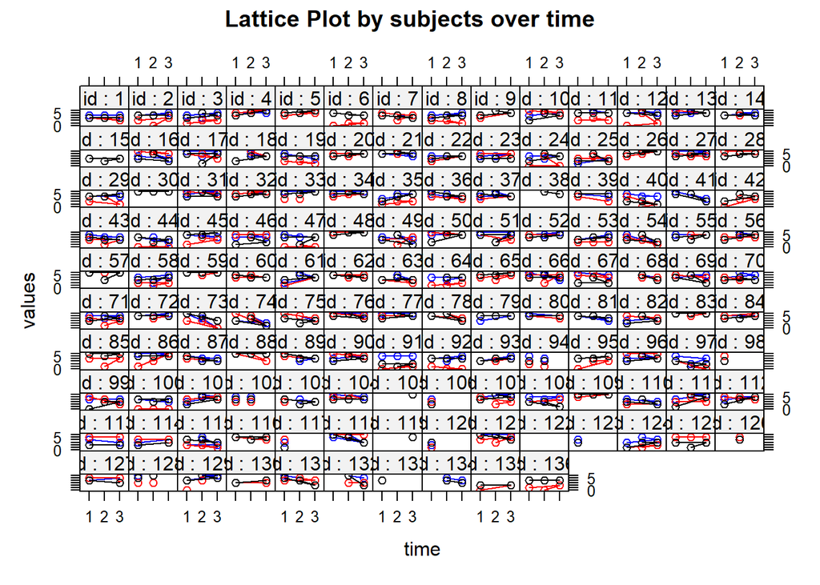

```r
mg <- mlr(data.frame(as.matrix(musical_absorption.wide.num)),grp="ID",Time="Piece",items=c("absorbed_music","sense_time","attentive"),plot=TRUE)# multilevel.reliability also works as the function call
```

```r
mg
```

```
##
## Multilevel Generalizability analysis
## Call: mlr(x = data.frame(as.matrix(musical_absorption.wide.num)), grp = "ID",
##     Time = "Piece", items = c("absorbed_music", "sense_time",
##         "attentive"), plot = TRUE)
##
## The data had  136  observations taken over  3  time intervals for  3 items.
##
##  Alternative estimates of reliability based upon Generalizability theory
##
## RkF  =  0.91 Reliability of average of all ratings across all items and  times (Fixed time effects)
## R1R  =  0.5 Generalizability of a single time point across all items (Random time effects)
## RkR  =  0.75 Generalizability of average time points across all items (Random time effects)
## Rc   =  0.67 Generalizability of change (fixed time points, fixed items)
## RkRn =  0.76 Generalizability of between person differences averaged over time (time nested within people)
## Rcn  =  0.29 Generalizability of within person variations averaged over items  (time nested within people)
##
##  These reliabilities are derived from the components of variance estimated by ANOVA
##              variance Percent
## ID               0.47    0.22
## Time             0.02    0.01
## Items            0.20    0.09
## ID x time        0.41    0.19
## ID x items       0.48    0.22
## time x items     0.01    0.00
## Residual         0.59    0.27
## Total            2.18    1.00
##
##  The nested components of variance estimated from lme are:
##          variance Percent
## id           0.68   0.309
## id(time)     0.18   0.083
## residual     1.34   0.608
## total        2.21   1.000
##
## To see the ANOVA and alpha by subject, use the short = FALSE option.
##  To see the summaries of the ICCs by subject and time, use all=TRUE
##  To see specific objects select from the following list:
##  ANOVA s.lmer s.lme alpha summary.by.person summary.by.time ICC.by.person ICC.by.time lmer long Call
```

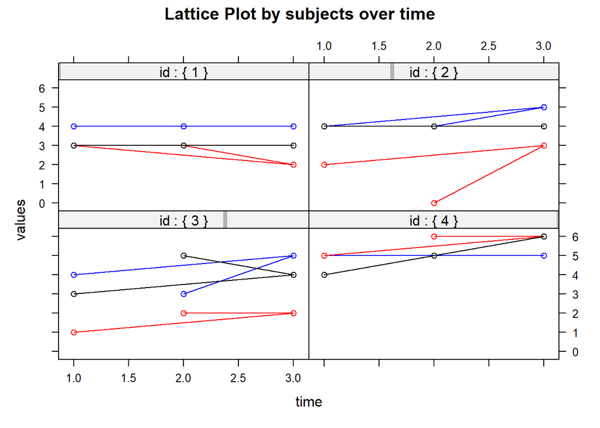

```r
#subset for plotting
subset_for_plotting<-musical_absorption.wide.num%>%filter(ID %in% c(1,2,3,4))

mlPlot(data.frame(as.matrix(subset_for_plotting)),grp="ID",Time = "Piece", items = c("absorbed_music","sense_time","attentive")) # before I changed data to data.frame(as.matrix(...),  I got this error: Error in unique.default(x, nmax = nmax) :
```

```r
#unique() applies only to vectors
```

Add this average into the dataframe

```r
df.full%<>%full_join(mus_abs, by = "Pt_ID")
```

# Explore the data

## Histograms of each of the variables

These are included in Table 1: Absorption, Attention, and Affect

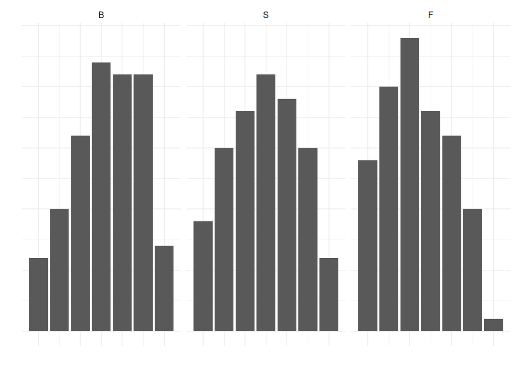

```r
items<-c("own_world", "absorbed_music", "daydream", "sense_time", "distracted", "attentive", "attention_others", "attention_sensations", "positively_transformed", "negatively_transformed")

df_absorption<-df.full%>%select("Pt_ID",group, contains(items))

df_absorption_nona<-na.omit(df_absorption)

df_absorb.long<-df_absorption_nona%>%pivot_longer(!c(Pt_ID,group),
                        names_to = c("question", "piece"),
                        names_pattern ="(.*)_(.*)",
                        values_to = "response")

df_absorb.wide<-df_absorb.long%>%pivot_wider(names_from = question, values_from = response)

df_absorb.wide$piece<-factor(df_absorb.wide$piece, levels = c("Beethoven", "Schnittke", "Folk"), labels = c("B", "S", "F"))

# own world
df_absorb.wide%>%select(piece, own_world)%>%drop_na()%>%
  ggplot(aes(x=own_world))+
    geom_bar(stat="count")+
    theme_minimal()+
    theme(axis.text.x=element_blank(),
          axis.text.y=element_blank())+
    labs(x = "", y = "")+
    facet_grid(cols = vars(piece))
```

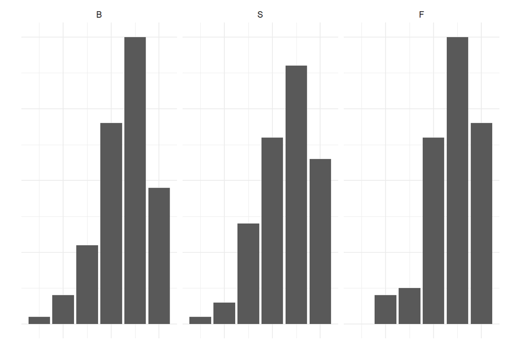

```r
graphname<-paste0("../revised_plots/hist_own_world.png")
ggsave(graphname,width = 4, height = 3, units = 'cm')

# absorbed music
df_absorb.wide%>%select(piece, absorbed_music)%>%drop_na()%>%
  ggplot(aes(x=absorbed_music))+
    geom_bar(stat="count")+
    theme_minimal()+
    theme(axis.text.x=element_blank(),
          axis.text.y=element_blank())+
    labs(x = "", y = "")+
    facet_grid(cols = vars(piece))
```

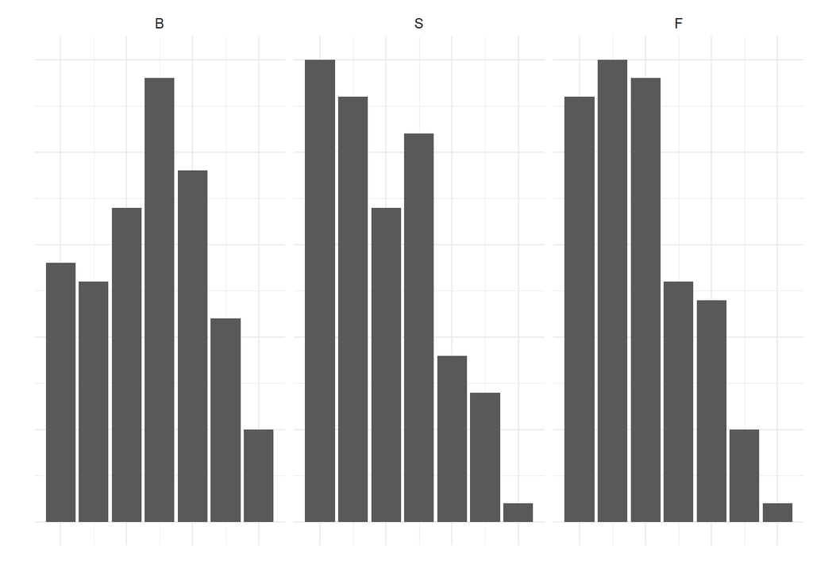

```r
graphname<-paste0("../revised_plots/hist_absorbed_music.png")
ggsave(graphname,width = 4, height = 3, units = 'cm')

# daydream
df_absorb.wide%>%select(piece, daydream)%>%drop_na()%>%
  ggplot(aes(x=daydream))+
    geom_bar(stat="count")+
    theme_minimal()+
    theme(axis.text.x=element_blank(),
          axis.text.y=element_blank())+
    labs(x = "", y = "")+
    facet_grid(cols = vars(piece))
```

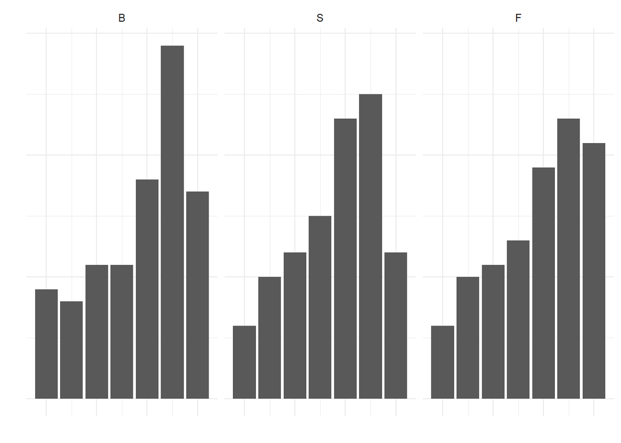

```r
graphname<-paste0("../revised_plots/hist_daydream.png")
ggsave(graphname,width = 4, height = 3, units = 'cm')

# sense time
df_absorb.wide%>%select(piece, sense_time)%>%drop_na()%>%
  ggplot(aes(x=sense_time))+
    geom_bar(stat="count")+
    theme_minimal()+
    theme(axis.text.x=element_blank(),
          axis.text.y=element_blank())+
    labs(x = "", y = "")+
    facet_grid(cols = vars(piece))
```

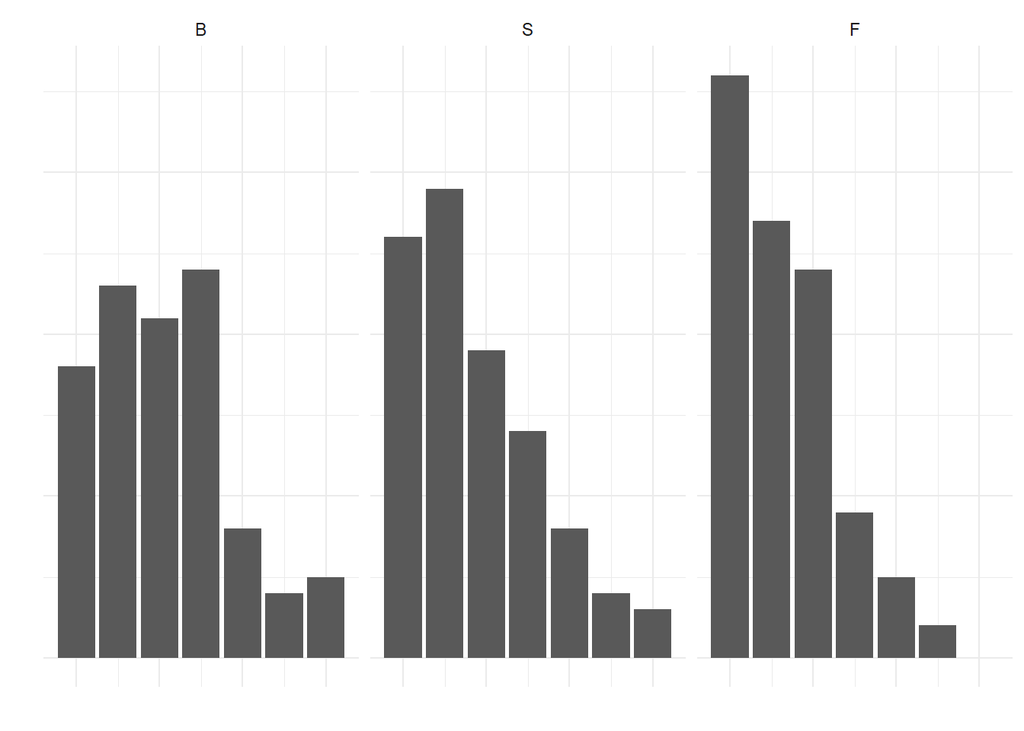

```r
graphname<-paste0("../revised_plots/hist_sensetime.png")
ggsave(graphname,width = 4, height = 3, units = 'cm')

# distracted
df_absorb.wide%>%select(piece, distracted)%>%drop_na()%>%
  ggplot(aes(x=distracted))+
    geom_bar(stat="count")+
    theme_minimal()+
    theme(axis.text.x=element_blank(),
          axis.text.y=element_blank())+
    labs(x = "", y = "")+
    facet_grid(cols = vars(piece))
```

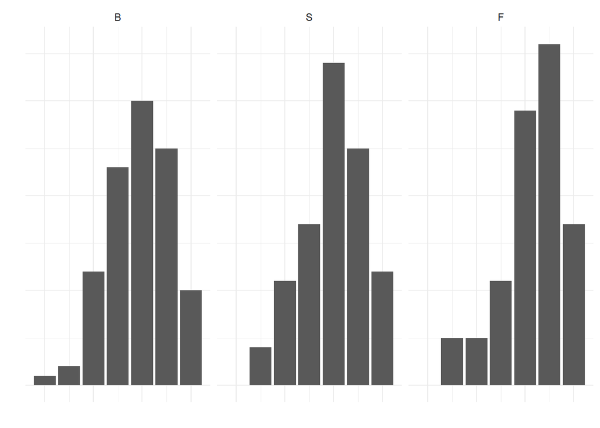

```r
graphname<-paste0("../revised_plots/hist_distracted.png")
ggsave(graphname,width = 4, height = 3, units = 'cm')

# attentive
df_absorb.wide%>%select(piece, attentive)%>%drop_na()%>%
  ggplot(aes(x=attentive))+
    geom_bar(stat="count")+
    theme_minimal()+
    theme(axis.text.x=element_blank(),
          axis.text.y=element_blank())+
    labs(x = "", y = "")+
    facet_grid(cols = vars(piece))
```

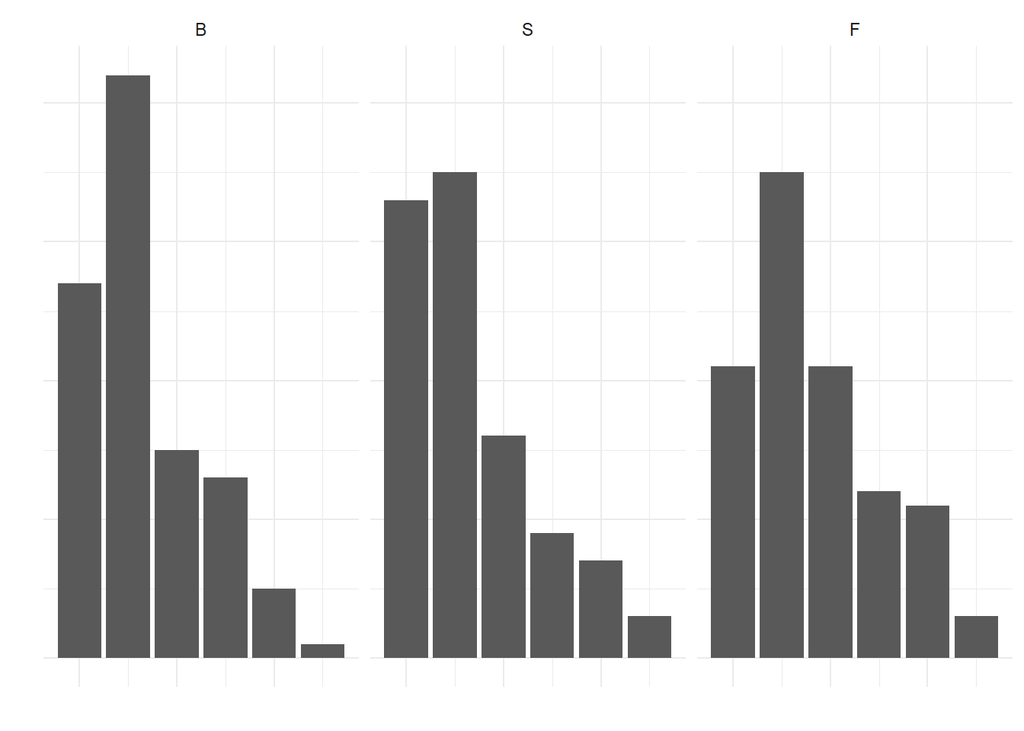

```r
graphname<-paste0("../revised_plots/hist_attentive.png")
ggsave(graphname,width = 4, height = 3, units = 'cm')

# attention others
df_absorb.wide%>%select(piece, attention_others)%>%drop_na()%>%
  ggplot(aes(x=attention_others))+
    geom_bar(stat="count")+
    theme_minimal()+
    theme(axis.text.x=element_blank(),
          axis.text.y=element_blank())+
    labs(x = "", y = "")+
    facet_grid(cols = vars(piece))
```

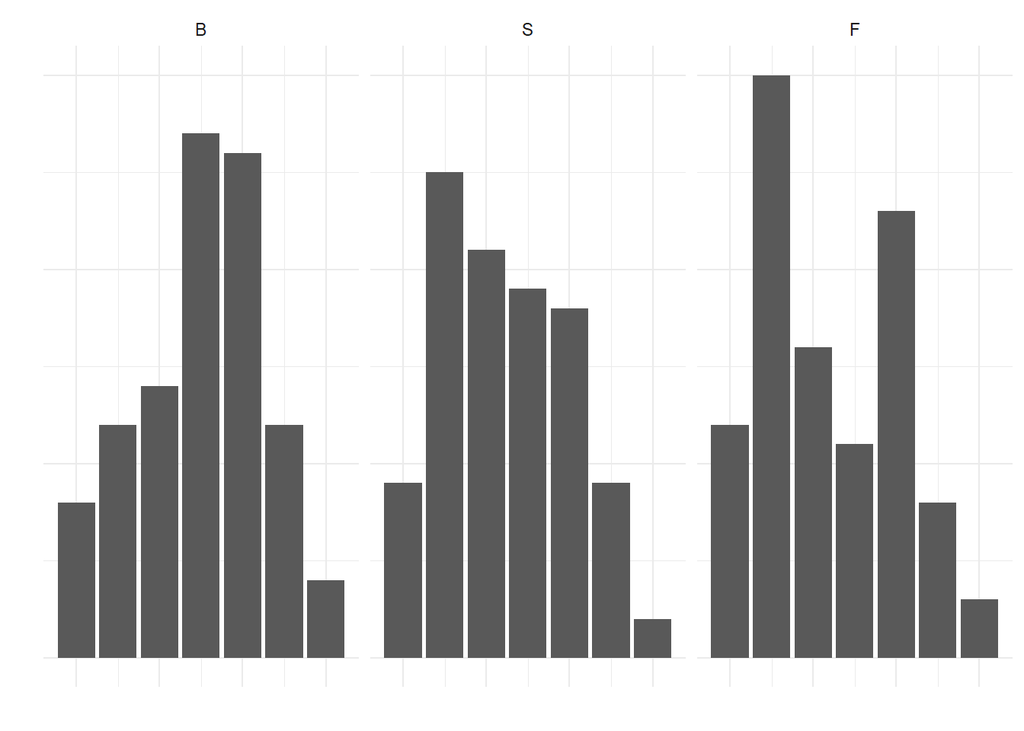

```r
graphname<-paste0("../revised_plots/hist_attention_others.png")
ggsave(graphname,width = 4, height = 3, units = 'cm')

# attention sensations
df_absorb.wide%>%select(piece, attention_sensations)%>%drop_na()%>%
  ggplot(aes(x=attention_sensations))+
    geom_bar(stat="count")+
    theme_minimal()+
    theme(axis.text.x=element_blank(),
          axis.text.y=element_blank())+
    labs(x = "", y = "")+
    facet_grid(cols = vars(piece))
```

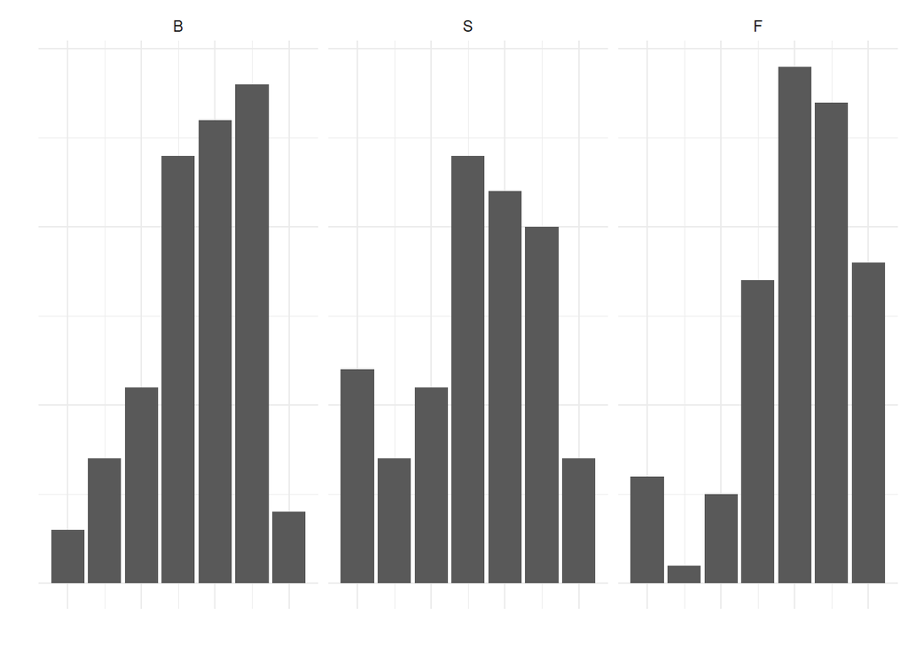

```r
graphname<-paste0("../revised_plots/hist_attention_sensations.png")
ggsave(graphname,width = 4, height = 3, units = 'cm')


# positive transformation
df_absorb.wide%>%select(piece, positively_transformed)%>%drop_na()%>%
  ggplot(aes(x=positively_transformed))+
    geom_bar(stat="count")+
    theme_minimal()+
    theme(axis.text.x=element_blank(),
          axis.text.y=element_blank())+
    labs(x = "", y = "")+
    facet_grid(cols = vars(piece))
```

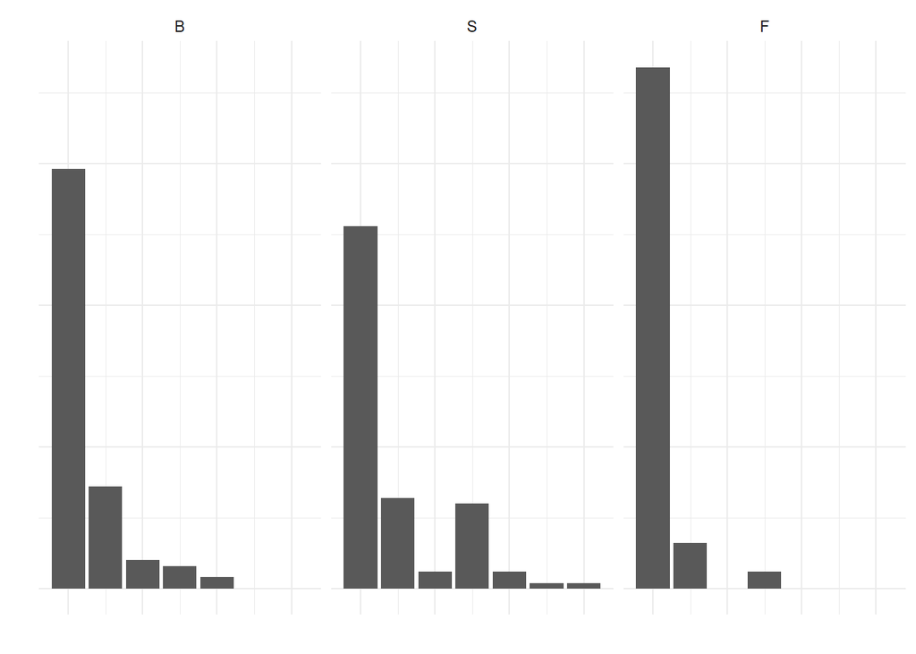

```r
graphname<-paste0("../revised_plots/hist_pos_transform.png")
ggsave(graphname,width = 4, height = 3, units = 'cm')

# negative transformation
df_absorb.wide%>%select(piece, negatively_transformed)%>%drop_na()%>%
  ggplot(aes(x=negatively_transformed))+
    geom_bar(stat="count")+
    theme_minimal()+
    theme(axis.text.x=element_blank(),
          axis.text.y=element_blank())+
    labs(x = "", y = "")+
    facet_grid(cols = vars(piece))
```

```r
graphname<-paste0("../revised_plots/hist_neg_transform.png")
ggsave(graphname,width = 4, height = 3, units = 'cm')
```

## Correlations between absorption items and positive and negative affect by piece.

This is located in the supplementary material in S4 and supplementary figure 2.

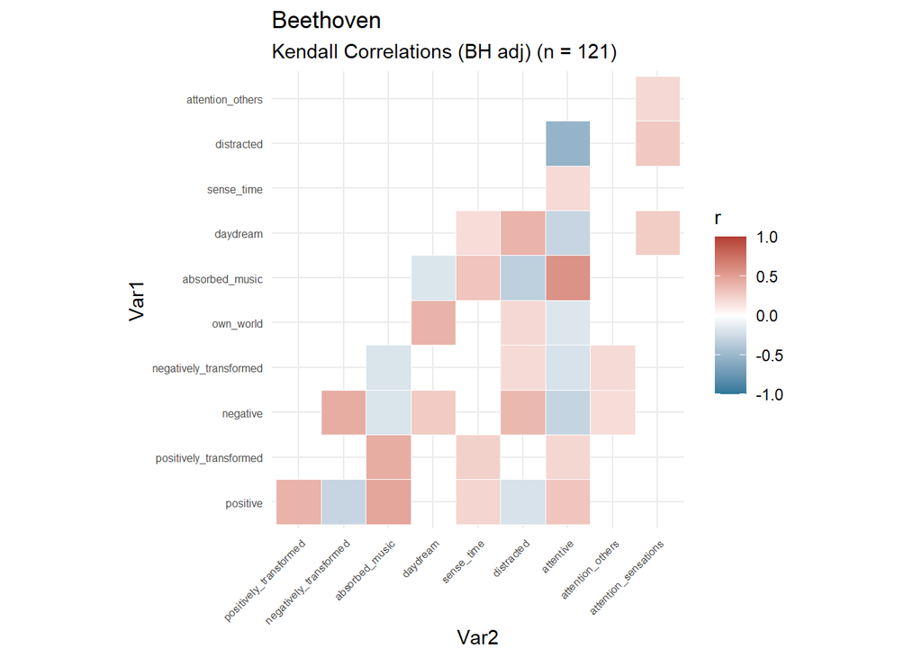

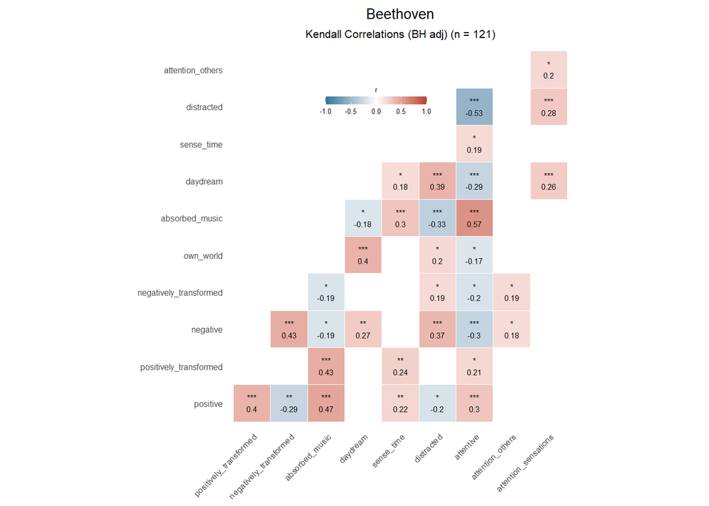

```r
items<-c("positive", "negative", "own_world", "absorbed_music", "daydream", "sense_time", "distracted", "attentive", "attention_others", "attention_sensations", "positively_transformed", "negatively_transformed")

df<-df.full%>%select("Pt_ID", contains(items))%>%select(-contains("Positive_Affect"))

df.long<-df%>%pivot_longer(!Pt_ID,
                        names_to = c("question", "piece"),
                        names_pattern ="(.*)_(.*)",
                        values_to = "response")

df.wide<-df.long%>%pivot_wider(names_from = question, values_from = response)

Beethoven<-df.wide%>%filter(piece == "Beethoven")
Schnittke<-df.wide%>%filter(piece == "Schnittke")
Folk<-df.wide%>%filter(piece == "Folk")

colours_DSQ<-c("#2d769a", "white","#b34036")

corData<-Beethoven%>%select(-Pt_ID, -piece)
corData<-na.omit(corData)
samples = nrow(corData)
title = "Beethoven"
subtitle = paste0("Kendall Correlations (BH adj) (n = ", samples, ")")
chart.correlation(corData, colours_DSQ, title, subtitle)
```

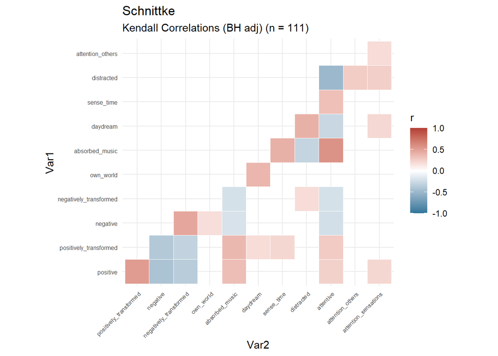

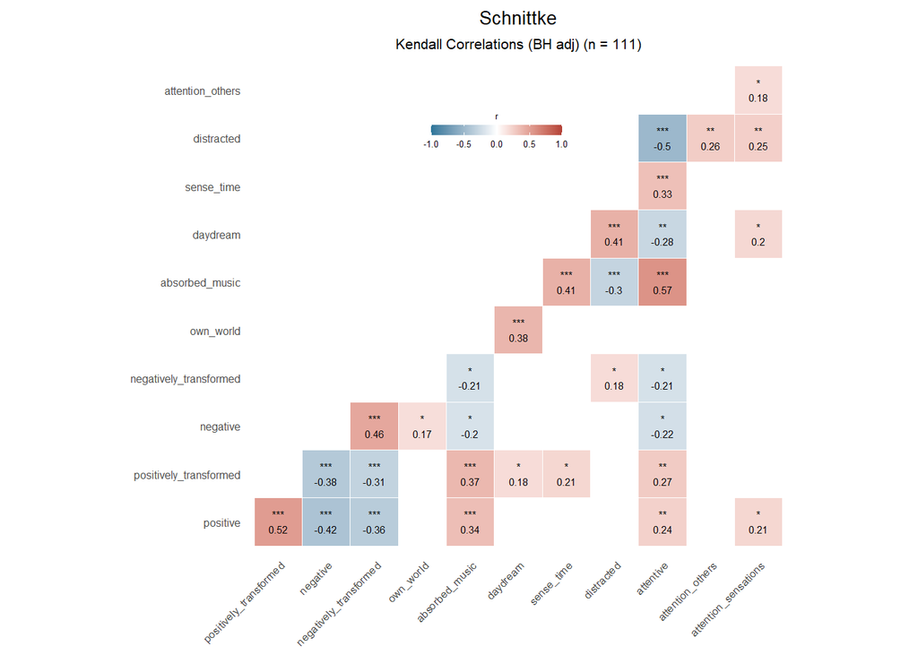

```r
# check the p-values
correlation = adj.cor(corData, p.adjust = TRUE, p.adjust.method = "BH", threshold = 0.05, cor.method = "kendall")

corData<-Schnittke%>%select(-Pt_ID, -piece)
corData<-na.omit(corData)
samples = nrow(corData)
title = "Schnittke"
subtitle = paste0("Kendall Correlations (BH adj) (n = ", samples, ")")
chart.correlation(corData, colours_DSQ, title, subtitle)
```

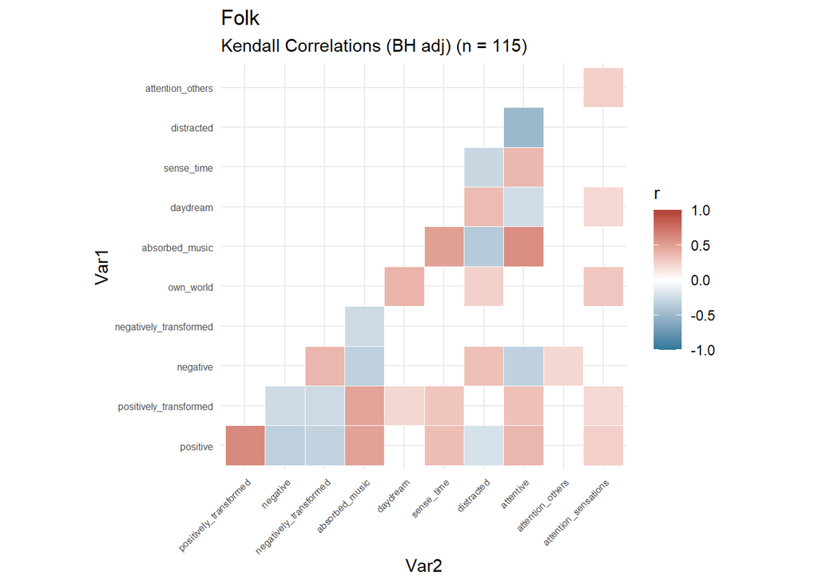

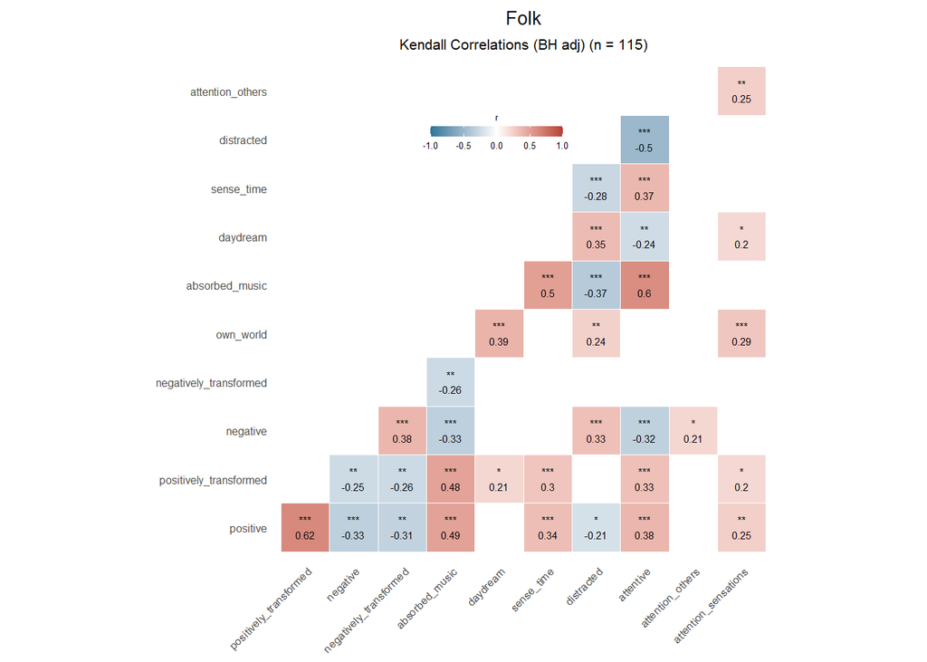

```r
# check the p-values
correlation = adj.cor(corData, p.adjust = TRUE, p.adjust.method = "BH", threshold = 0.05, cor.method = "kendall")

corData<-Folk%>%select(-Pt_ID, -piece)
corData<-na.omit(corData)
samples = nrow(corData)
title = "Folk"
subtitle = paste0("Kendall Correlations (BH adj) (n = ", samples, ")")
chart.correlation(corData, colours_DSQ, title, subtitle)
```

```r
# check the p-values
correlation = adj.cor(corData, p.adjust = TRUE, p.adjust.method = "BH", threshold = 0.05, cor.method = "kendall")

graphname<-paste0("../revised_plots/", title, "_pos_neg_correlation.png")
ggsave(graphname, width = 12, height = 10, units = 'cm', dpi = 500)
```

## Transformation and Feelings

Check the mean and standard deviation of positive and negative transformation and feelings. This is reported in Supplementary Table 1.

```r
feelings_transformation<-df.full%>%select(Pt_ID, contains(c("transformed", "positive", "negative")))%>%pivot_longer(!Pt_ID, names_to = c("var", "piece"),names_pattern ="(.*)_(.*)", values_to = "response")%>%
  group_by(piece, var)%>%summarise(m = mean(response, na.rm = TRUE), sd = sd(response, na.rm = TRUE), n = n())%>%pivot_wider(names_from = "var", values_from = c("m", "sd"))
feelings_transformation
```

```
## # A tibble: 3 × 10
## # Groups:   piece [3]
##   piece         n m_negative m_negatively_transformed m_positive
##   <chr>     <int>      <dbl>                    <dbl>      <dbl>
## 1 Beethoven   136      0.945                    0.417       4.88
## 2 Folk        136      0.275                    0.160       5.12
## 3 Schnittke   136      1.69                     0.888       3.86
## # ℹ 5 more variables: m_positively_transformed <dbl>, sd_negative <dbl>,
## #   sd_negatively_transformed <dbl>, sd_positive <dbl>,
## #   sd_positively_transformed <dbl>
```

# 3.3 Repeated Measures Correlations

Section 3.3 What is the relation between absorption in the music, the other attention/affect items, and other affective variables?

Correlations between variables by piece needs to be conducted with a repeated measures approach because we measured the scales after Beethoven, Schnittke, and the Folk (3 times)

There is a toolbox that was developed just for this kind of analysis called rmcorr (Bakdash & Marusich, 2017). https://www.frontiersin.org/articles/10.3389/fpsyg.2017.00456/full

“Rmcorr accounts for non-independence among observations using analysis of covariance (ANCOVA) to statistically adjust for inter-individual variability. By removing measured variance between-participants, rmcorr provides the best linear fit for each participant using parallel regression lines (the same slope) with varying intercepts. Like a Pearson correlation coefficient (r), the rmcorr coefficient (rrm) is bounded by −1 to 1 and represents the strength of the linear association between two variables. Also akin to the Pearson correlation, the null hypothesis for rmcorr is ρrm = 0, and the research/alternative hypothesis is ρrm 6= 0. Unlike the Pearson correlation, which assesses the inter-individual association because it assumes each paired data point is Independent and Identically Distributed (IID), rmcorr evaluates the overall or common intra-individual association between two measures. Because rmcorr takes into account non-independence, it tends to yield much greater power than data that are averaged in order to meet the IID assumption for simple regression/correlation. Hence, rmcorr can detect associations between variables that might otherwise be obscured or spurious due to aggregation or treating non-independent values as IID.

Conceptually, rmcorr is close to a null multilevel model (i.e., varying intercept and a common slope for each individual), but the techniques differ on how they treat/pool variance. Rmcorr assesses the common intra-individual variance in data, whereas multilevel modeling can simultaneously analyze different sources of variance using fixed and random effects. The tradeoff with more complex multilevel models is that they require more data and are more challenging to specify and interpret than simpler analysis of variance (ANOVA)/regression models, such as rmcorr. However, the flexibility of multilevel modeling has benefits: Overall and individual differences can be analyzed simultaneously, models of varying complexity can be systematically compared, and they can provide greater insights into individual differences.”

“Rmcorr can be viewed as a “light” version of multilevel modeling because it is comparable to a simple, null multilevel model with random/varying effects of intercept for each individual and a fixed effect (i.e., common/overall) slope (see Appendix C for direct comparisons). However, rmcorr only analyzes intra- individual variance. Multilevel modeling can simultaneously analyze both intra- and inter-individual variance using partial pooling, which permits varying slopes and other parameters that cannot be estimated with simpler techniques.

## Correlation Matrix

This is figure 1 in the manuscript, located in section 3.3

Did not include motion (QoM) and stilling because we might expect the relation between absorption and motion to be different for different pieces due to the sociocultural genre constraints.

```r
attention_items<-c("distracted","attention_others", "attention_sensations")
transformation_items<-c("positively_transformed", "negatively_transformed")
daydream_items<-c("own_world", "daydream")

# execute the code so that you know you have the correct data
cormat_df<-df.full%>%select(Pt_ID,contains("mus_abs"), contains(attention_items), contains(transformation_items),contains(daydream_items), contains("KM"), contains("AWE_wonder"), contains("connected_musicians"), contains("connected_audience"), contains("familiar"),contains("enjoy"))

cormat_df.long<-cormat_df%>%pivot_longer(!Pt_ID,
                        names_to = c("var", "piece"),
                        names_pattern ="(.*)_(.*)",
                        values_to = "response")

cormat_df.long<-cormat_df.long%>%filter(var != "connected_audience_streaming", var != "connected_audience_attending")

cormat_df.wide<-pivot_wider(cormat_df.long, names_from = var, values_from = response)
# rename the vars so they appear pretty in the chart
colnames(cormat_df.wide)<-c("Pt_ID", "piece", "Absorption","Distracted","Attention Others", "Attention Sensations", "Positive Transformation", "Negative Transformation", "Own World","Daydream", "Kama Muta","Awe", "Connected Musicians", "Connected Audience","Familiar","Enjoyment")

variables<-c("Absorption","Distracted","Attention Others", "Attention Sensations", "Positive Transformation", "Negative Transformation", "Own World","Daydream", "Kama Muta","Awe", "Connected Musicians", "Connected Audience","Familiar","Enjoyment")

cormat_df.wide%<>%filter(piece !="Bach")

# removing NA does change the results. Therefore proceed with caution.
#cormat_df.wide%<>%na.omit()

rmc_mat<-rmcorr_mat(Pt_ID, variables, cormat_df.wide, CI.level = 0.95)
```

In the next cell, I need to adjust the rmc_mat so that I only have the matrix that I want visualized.

```r
# filter such that measure 1 contains only the absorption items
absorb_item_names<-c("Absorption","Distracted","Attention Others", "Attention Sensations", "Positive Transformation", "Negative Transformation", "Own World","Daydream")
adjusted_summary<-rmc_mat$summary%>%filter(measure1 %in% absorb_item_names)
```

Then create corrected p-values (correction = FDR adjustment)

```r
adjusted_matrix<-rmc_mat$matrix[1:length(absorb_item_names), 2:length(variables)]
r.mat<-adjusted_matrix
```

```r
# use the rm_adjusted.corr function outside of the function to be able to check that everything is working. -- the following code is copy pasted and adjusted based on that function.

# assign function variables
cor_df<-cormat_df.wide%>%dplyr::select(-Pt_ID, -piece)
p.adjust = TRUE
p.adjust.method = "fdr"

# p.adjust methods: # c("holm", "hochberg", "hommel", "bonferroni", "BH", "BY",
#   "fdr", "none") # Lol: note that BH and FDR are the same method (it seems) https://support.bioconductor.org/p/110897/#:~:text=%22BH%22%20and%20%22fdr%22%20are%20the%20same%20method.,an%20alias%20for%20%22BH%22.

threshold = 0.05
cor.method = "repeated"

if (p.adjust==TRUE){
  p.vals <- p.adjust(adjusted_summary$p.vals,
                     method = p.adjust.method,
                     n = length(adjusted_summary$p.vals))
} else {
  p.vals = adjusted_summary$p.vals
}

# initiate empty matrix for the p-values only
MAT = matrix(NA, nrow = length(unique(adjusted_summary$measure1)), ncol = length(unique(adjusted_summary$measure2)))

rownames(MAT) = unique(adjusted_summary$measure1)
colnames(MAT) = unique(adjusted_summary$measure2)

# starting to convert p.list to p.values matrix
for(ind in 1:(length(p.vals))){
  var1 = adjusted_summary$measure1[ind] # var1
  var2 = adjusted_summary$measure2[ind] # var1
  p.value = p.vals[ind] # p value
  MAT[var1, var2] = p.value
}

# At this point, MAT has the p.values in a matrix

# subset only the coefficients with p values < 0.05 (or than the specified threshold)

subset = ifelse(MAT < threshold, r.mat, NA)

output = list(adj.p.values = MAT, threshold.r = subset)
```

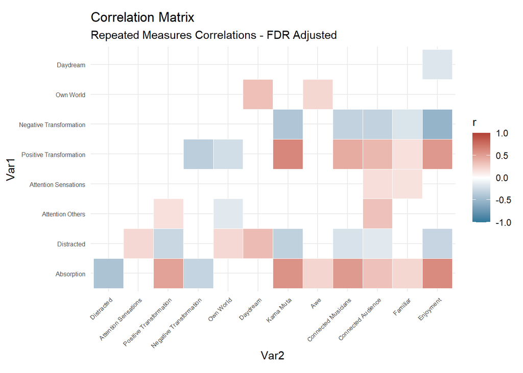

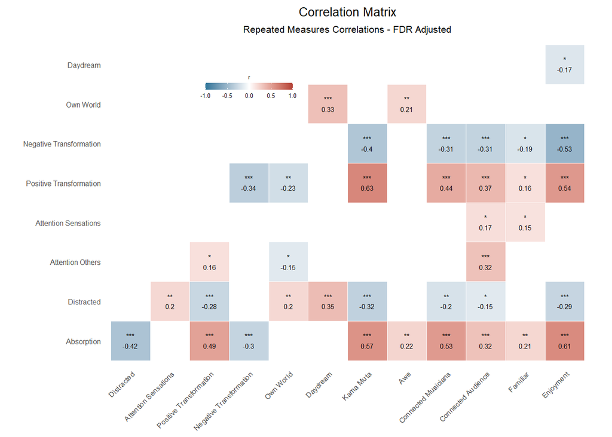

```r
Title = "Correlation Matrix"
colours_blue_white_red<-c("#2d769a", "white","#b34036") # update colors as you wish
Subtitle = "Repeated Measures Correlations - FDR Adjusted"
rm_correlation.matrix(output, colours_blue_white_red, Title, Subtitle)
```

```r
graphname<-paste0("../revised_plots/RM_Correlations_continuous_fdr_nona.png")
ggsave(graphname, width = 12, height = 10, units = 'cm', dpi = 500, bg = "white")

#graphname<-paste0("../revised_plots/Publication_Figures/RM_Correlations_continuous_fdr.jpg")
#ggsave(graphname, width = 12, height = 10, units = 'cm', dpi = 500, bg = "white")
```

Inspect the rmcorr values and p-values to write the results section

```r
output
```

```
## $adj.p.values
##                           Distracted Attention Others Attention Sensations
## Absorption              1.473489e-10        0.6312698          0.822304744
## Distracted                        NA        0.9925089          0.005272645
## Attention Others                  NA               NA          0.598017982
## Attention Sensations              NA               NA                   NA
## Positive Transformation           NA               NA                   NA
## Negative Transformation           NA               NA                   NA
## Own World                         NA               NA                   NA
## Daydream                          NA               NA                   NA
##                         Positive Transformation Negative Transformation
## Absorption                         1.291877e-14            1.541653e-05
## Distracted                         5.420339e-05            1.406313e-01
## Attention Others                   3.210894e-02            8.536824e-01
## Attention Sensations               2.386975e-01            9.145061e-01
## Positive Transformation                      NA            4.269263e-07
## Negative Transformation                      NA                      NA
## Own World                                    NA                      NA
## Daydream                                     NA                      NA
##                           Own World     Daydream    Kama Muta         Awe
## Absorption              0.777069734 6.413229e-02 6.284507e-20 0.002173972
## Distracted              0.004910133 1.096129e-07 2.482767e-06 0.990417152
## Attention Others        0.042843446 6.296956e-01 2.104680e-01 0.559629602
## Attention Sensations    0.154344297 5.833951e-02 2.306241e-01 0.568650663
## Positive Transformation 0.001246934 1.836460e-01 1.306097e-25 0.686069776
## Negative Transformation 0.940341934 6.947287e-01 1.818838e-09 0.914506086
## Own World                        NA 1.092417e-06 8.285993e-02 0.003496214
## Daydream                         NA           NA 6.966699e-02 0.727130359
##                         Connected Musicians Connected Audience    Familiar
## Absorption                     1.424908e-16       6.301822e-06 0.003785199
## Distracted                     5.855892e-03       4.284345e-02 0.617594579
## Attention Others               7.770697e-01       4.429771e-06 0.914506086
## Attention Sensations           4.271888e-01       2.357575e-02 0.042843446
## Positive Transformation        1.806185e-11       6.786177e-08 0.032108942
## Negative Transformation        9.050215e-06       6.301822e-06 0.012085044
## Own World                      3.786658e-01       1.375729e-01 0.777069734
## Daydream                       1.375729e-01       9.206104e-01 0.686069776
##                            Enjoyment
## Absorption              1.477147e-22
## Distracted              2.076164e-05
```

[output cut: 38 more lines]

```
## Attention Others                         NA          0.3208417         NA
## Attention Sensations                     NA          0.1711922  0.1538056
## Positive Transformation           0.4433950          0.3698457  0.1620584
## Negative Transformation          -0.3072302         -0.3143944 -0.1862860
## Own World                                NA                 NA         NA
## Daydream                                 NA                 NA         NA
##                          Enjoyment
## Absorption               0.6080299
## Distracted              -0.2940496
## Attention Others                NA
## Attention Sensations            NA
## Positive Transformation  0.5436953
## Negative Transformation -0.5253717
## Own World                       NA
## Daydream                -0.1721822
```

```r
output$adj.p.values
```

```
##                           Distracted Attention Others Attention Sensations
## Absorption              1.473489e-10        0.6312698          0.822304744
## Distracted                        NA        0.9925089          0.005272645
## Attention Others                  NA               NA          0.598017982
## Attention Sensations              NA               NA                   NA
## Positive Transformation           NA               NA                   NA
## Negative Transformation           NA               NA                   NA
## Own World                         NA               NA                   NA
## Daydream                          NA               NA                   NA
##                         Positive Transformation Negative Transformation
## Absorption                         1.291877e-14            1.541653e-05
## Distracted                         5.420339e-05            1.406313e-01
## Attention Others                   3.210894e-02            8.536824e-01
## Attention Sensations               2.386975e-01            9.145061e-01
## Positive Transformation                      NA            4.269263e-07
## Negative Transformation                      NA                      NA
## Own World                                    NA                      NA
## Daydream                                     NA                      NA
##                           Own World     Daydream    Kama Muta         Awe
## Absorption              0.777069734 6.413229e-02 6.284507e-20 0.002173972
## Distracted              0.004910133 1.096129e-07 2.482767e-06 0.990417152
## Attention Others        0.042843446 6.296956e-01 2.104680e-01 0.559629602
## Attention Sensations    0.154344297 5.833951e-02 2.306241e-01 0.568650663
## Positive Transformation 0.001246934 1.836460e-01 1.306097e-25 0.686069776
## Negative Transformation 0.940341934 6.947287e-01 1.818838e-09 0.914506086
## Own World                        NA 1.092417e-06 8.285993e-02 0.003496214
## Daydream                         NA           NA 6.966699e-02 0.727130359
##                         Connected Musicians Connected Audience    Familiar
## Absorption                     1.424908e-16       6.301822e-06 0.003785199
## Distracted                     5.855892e-03       4.284345e-02 0.617594579
## Attention Others               7.770697e-01       4.429771e-06 0.914506086
## Attention Sensations           4.271888e-01       2.357575e-02 0.042843446
## Positive Transformation        1.806185e-11       6.786177e-08 0.032108942
## Negative Transformation        9.050215e-06       6.301822e-06 0.012085044
## Own World                      3.786658e-01       1.375729e-01 0.777069734
## Daydream                       1.375729e-01       9.206104e-01 0.686069776
##                            Enjoyment
## Absorption              1.477147e-22
## Distracted              2.076164e-05
## Attention Others        7.770697e-01
## Attention Sensations    6.564522e-01
## Positive Transformation 8.176845e-18
## Negative Transformation 1.513835e-16
## Own World               9.403419e-01
## Daydream                2.177181e-02
```

```r
output$threshold.r
```

```
##                         Distracted Attention Others Attention Sensations
## Absorption              -0.4213057               NA                   NA
## Distracted                      NA               NA            0.1994771
## Attention Others                NA               NA                   NA
## Attention Sensations            NA               NA                   NA
## Positive Transformation         NA               NA                   NA
## Negative Transformation         NA               NA                   NA
## Own World                       NA               NA                   NA
## Daydream                        NA               NA                   NA
##                         Positive Transformation Negative Transformation
## Absorption                            0.4917433              -0.2972959
## Distracted                           -0.2753811                      NA
## Attention Others                      0.1595177                      NA
## Attention Sensations                         NA                      NA
## Positive Transformation                      NA              -0.3409670
## Negative Transformation                      NA                      NA
## Own World                                    NA                      NA
## Daydream                                     NA                      NA
##                          Own World  Daydream  Kama Muta       Awe
## Absorption                      NA        NA  0.5673216 0.2237006
## Distracted               0.2018969 0.3545686 -0.3185305        NA
## Attention Others        -0.1510799        NA         NA        NA
## Attention Sensations            NA        NA         NA        NA
## Positive Transformation -0.2286085        NA  0.6267741        NA
## Negative Transformation         NA        NA -0.3965262        NA
## Own World                       NA 0.3292409         NA 0.2126017
## Daydream                        NA        NA         NA        NA
##                         Connected Musicians Connected Audience   Familiar
## Absorption                        0.5318154          0.3176573  0.2131897
## Distracted                       -0.2010558         -0.1536335         NA
## Attention Others                         NA          0.3208417         NA
## Attention Sensations                     NA          0.1711922  0.1538056
## Positive Transformation           0.4433950          0.3698457  0.1620584
## Negative Transformation          -0.3072302         -0.3143944 -0.1862860
## Own World                                NA                 NA         NA
## Daydream                                 NA                 NA         NA
##                          Enjoyment
## Absorption               0.6080299
## Distracted              -0.2940496
## Attention Others                NA
## Attention Sensations            NA
## Positive Transformation  0.5436953
## Negative Transformation -0.5253717
## Own World                       NA
## Daydream                -0.1721822
```

### Split live and livestreaming audiences for correlation chart visualizations

To better understand how the different audiences/social contexts influence the relation between variables, split the data into groups. This is included in the supplementary material figure 2.

#### Live

```r
cormat_df<-df.full%>%select(Pt_ID,group,contains("mus_abs"), contains(attention_items), contains(transformation_items),contains(daydream_items), contains("KM"), contains("AWE_wonder"), contains("connected_musicians"), contains("connected_audience"), contains("familiar"),contains("enjoy")) #,  contains("mQoM"), contains("Stilling"))

cormat_df_live<-cormat_df%>%filter(group == "Live")

cormat_df_live.long<-cormat_df_live%>%pivot_longer(!c(Pt_ID,group),
                        names_to = c("var", "piece"),
                        names_pattern ="(.*)_(.*)",
                        values_to = "response")

cormat_df_live.long<-cormat_df_live.long%>%filter(var != "connected_audience_streaming", var != "connected_audience_attending")

cormat_df_live.long<-cormat_df_live.long%>%select(-group)

cormat_df_live.wide<-pivot_wider(cormat_df_live.long, names_from = var, values_from = response)
```

```r
colnames(cormat_df_live.wide)
```

```
##  [1] "Pt_ID"                  "piece"                  "mus_abs"
##  [4] "distracted"             "attention_others"       "attention_sensations"
##  [7] "positively_transformed" "negatively_transformed" "own_world"
## [10] "daydream"               "KM"                     "AWE_wonder"
## [13] "connected_musicians"    "connected_audience"     "familiar"
## [16] "enjoy"
```

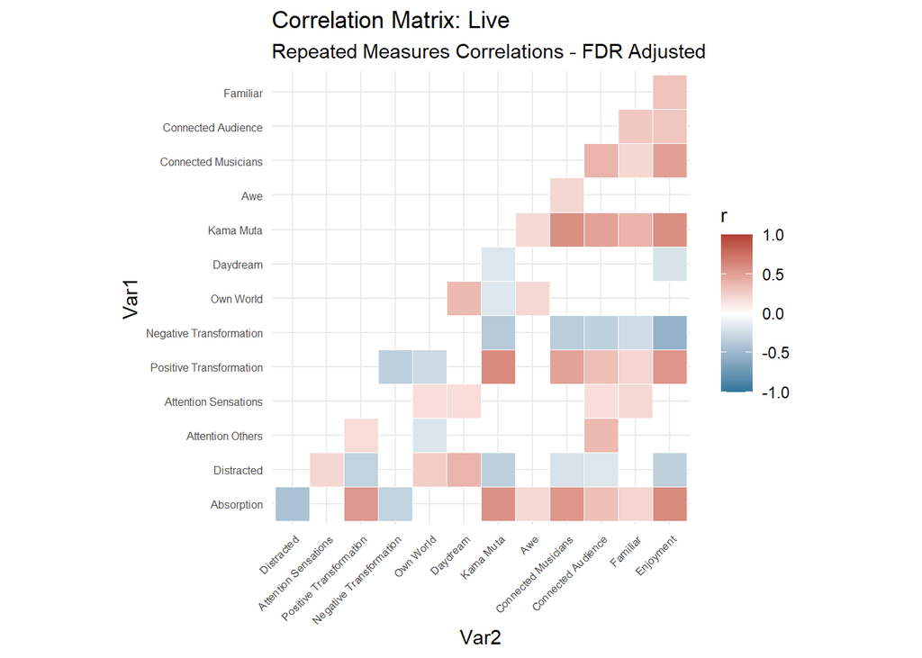

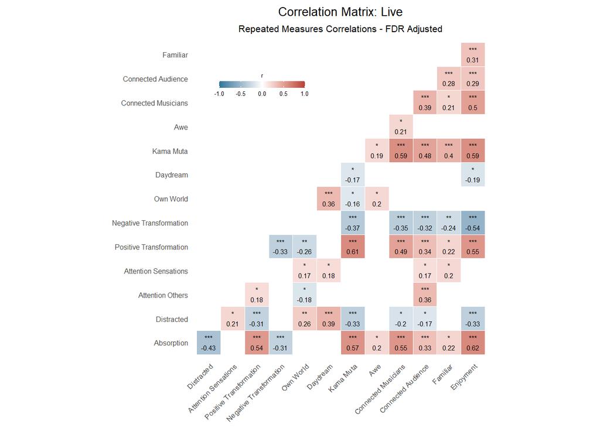

```r
# rename the vars so they appear pretty in the chart
colnames(cormat_df_live.wide)<-c("Pt_ID", "piece", "Absorption","Distracted","Attention Others", "Attention Sensations", "Positive Transformation", "Negative Transformation", "Own World","Daydream", "Kama Muta","Awe", "Connected Musicians", "Connected Audience","Familiar","Enjoyment")

cor_df<-cormat_df_live.wide%>%dplyr::select(-Pt_ID, -piece)

variables<-c("Absorption","Distracted","Attention Others", "Attention Sensations", "Positive Transformation", "Negative Transformation", "Own World","Daydream", "Kama Muta","Awe", "Connected Musicians", "Connected Audience","Familiar","Enjoyment")

rmc_mat<-rmcorr_mat(Pt_ID, variables, cormat_df_live.wide, CI.level = 0.95)

# create corrected p-values (correction = FDR adjustment)
correlation_fdr = rm_adjusted.corr(rmc_mat, cor_df, p.adjust = TRUE, p.adjust.method = "fdr", threshold = 0.05, cor.method = "repeated")

Title = "Correlation Matrix: Live"

colours_blue_white_red<-c("#2d769a", "white","#b34036") # update colors as you wish

Subtitle = "Repeated Measures Correlations - FDR Adjusted"
rm_correlation.matrix(correlation_fdr, colours_blue_white_red, Title, Subtitle)
```

```r
graphname<-paste0("../revised_plots/RM_Correlations_live.png")

ggsave(graphname, width = 12, height = 10, units = 'cm', dpi = 500)
```

#### Livestreaming

```r
cormat_df<-df.full%>%select(Pt_ID,group,contains("mus_abs"), contains(attention_items), contains(transformation_items),contains(daydream_items), contains("KM"), contains("AWE_wonder"), contains("connected_musicians"), contains("connected_audience"), contains("familiar"),contains("enjoy"))

cormat_df_livestreaming<-cormat_df%>%filter(group == "Virtual")

cormat_df_livestreaming.long<-cormat_df_livestreaming%>%pivot_longer(!c(Pt_ID,group),
                        names_to = c("var", "piece"),
                        names_pattern ="(.*)_(.*)",
                        values_to = "response")

cormat_df_livestreaming.long<-cormat_df_livestreaming.long%>%filter(var != "connected_audience_streaming", var != "connected_audience_attending")

cormat_df_livestreaming.long<-cormat_df_livestreaming.long%>%select(-group)

cormat_df_livestream.wide<-pivot_wider(cormat_df_livestreaming.long, names_from = var, values_from = response)
```

```r
colnames(cormat_df_livestream.wide)
```

```
##  [1] "Pt_ID"                  "piece"                  "mus_abs"
##  [4] "distracted"             "attention_others"       "attention_sensations"
##  [7] "positively_transformed" "negatively_transformed" "own_world"
## [10] "daydream"               "KM"                     "AWE_wonder"
## [13] "connected_musicians"    "connected_audience"     "familiar"
## [16] "enjoy"
```

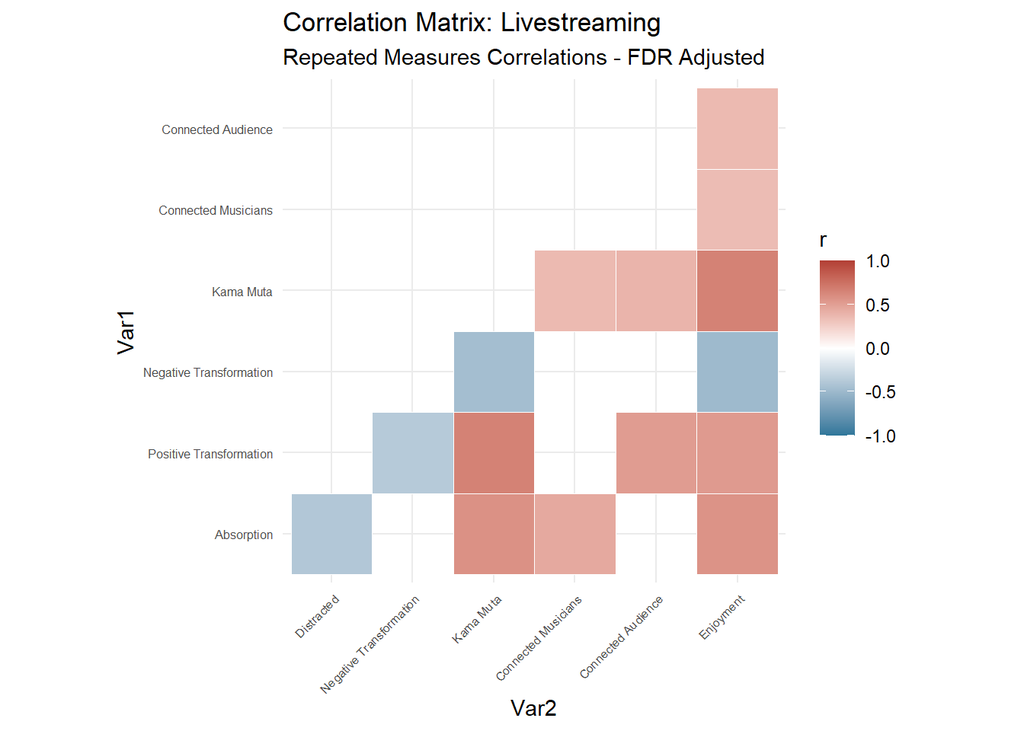

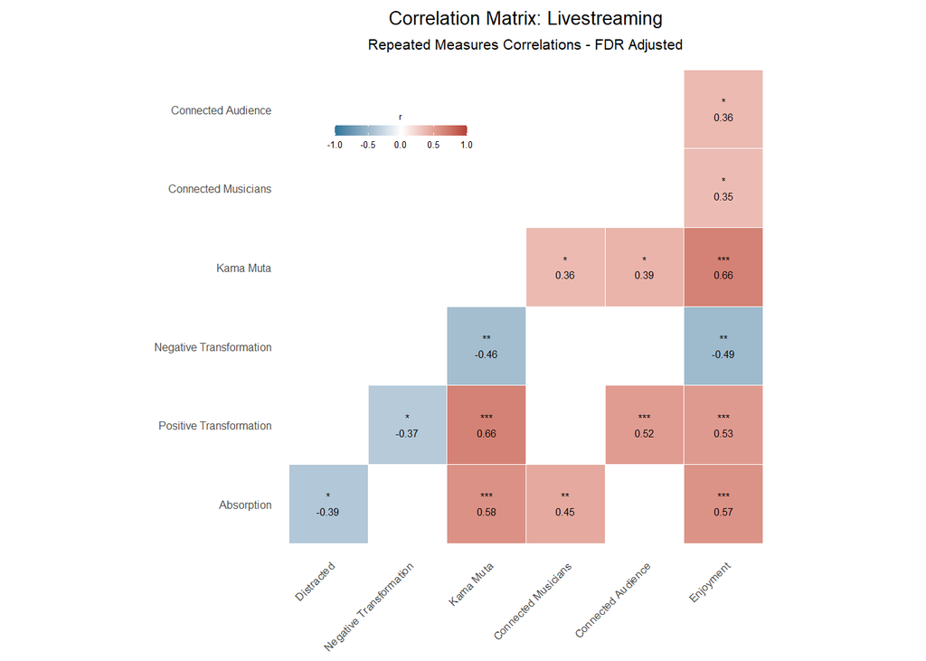

```r
# rename the vars so they appear pretty in the chart
colnames(cormat_df_livestream.wide)<-c("Pt_ID", "piece", "Absorption","Distracted","Attention Others", "Attention Sensations", "Positive Transformation", "Negative Transformation", "Own World","Daydream", "Kama Muta","Awe", "Connected Musicians", "Connected Audience","Familiar","Enjoyment")

cor_df<-cormat_df_livestream.wide%>%dplyr::select(-Pt_ID, -piece)

variables<-c("Absorption","Distracted","Attention Others", "Attention Sensations", "Positive Transformation", "Negative Transformation", "Own World","Daydream", "Kama Muta","Awe", "Connected Musicians", "Connected Audience","Familiar","Enjoyment")

rmc_mat<-rmcorr_mat(Pt_ID, variables, cormat_df_livestream.wide, CI.level = 0.95)

# create corrected p-values (correction = FDR adjustment)
correlation_fdr = rm_adjusted.corr(rmc_mat, cor_df, p.adjust = TRUE, p.adjust.method = "fdr", threshold = 0.05, cor.method = "repeated")

Title = "Correlation Matrix: Livestreaming"

colours_blue_white_red<-c("#2d769a", "white","#b34036") # update colors as you wish

Subtitle = "Repeated Measures Correlations - FDR Adjusted"
rm_correlation.matrix(correlation_fdr, colours_blue_white_red, Title, Subtitle)
```

```r
graphname<-paste0("../revised_plots/RM_Correlations_livestreaming.png")

ggsave(graphname, width = 12, height = 10, units = 'cm', dpi = 500)
```

#### AIMS and Awe

In related research: Trait-based measures of absorption predict awe and instructing people to be absorbed in their experience also increases the experience of awe (van Elk et al., 2016). Therefore, check whether AIMS predicted AWE. First try separate linear models.

```r
# get data
df_awe_aims<-df.full%>%select(Pt_ID, AIMS, group, contains("AWE"))

# make long
df_awe_aims.long<-df_awe_aims%>%pivot_longer(!c(Pt_ID, AIMS, group), #make long
                            names_to = c("var", "piece"),
                            names_pattern ="(.*)_(.*)",
                            values_to = "response")

df_awe_aims.wide<-df_awe_aims.long%>%pivot_wider(names_from = var, values_from = response)

df_awe_aims.wide$piece<-factor(df_awe_aims.wide$piece, levels = c("Beethoven", "Schnittke", "Bach", "Folk"))
#factor for the correct facet order

df_awe_aims.wide_nona<-df_awe_aims.wide%>%drop_na() #408 to 351
```

```r
baseline_awe<-lmer(AWE_wonder ~ 1 + (1|Pt_ID), data = df_awe_aims.wide_nona, REML = FALSE)
awe_aims<-lmer(AWE_wonder ~ AIMS + (1|Pt_ID), data = df_awe_aims.wide_nona, REML = FALSE)

anova(baseline_awe, awe_aims)
```

```
## Data: df_awe_aims.wide_nona
## Models:
## baseline_awe: AWE_wonder ~ 1 + (1 | Pt_ID)
## awe_aims: AWE_wonder ~ AIMS + (1 | Pt_ID)
##              npar    AIC    BIC  logLik deviance Chisq Df Pr(>Chisq)
## baseline_awe    3 969.13 980.71 -481.57   963.13
## awe_aims        4 959.91 975.35 -475.96   951.91 11.22  1   0.000809 ***
## ---
## Signif. codes:  0 '***' 0.001 '**' 0.01 '*' 0.05 '.' 0.1 ' ' 1
```

```r
summary(awe_aims)
```

```
## Linear mixed model fit by maximum likelihood  ['lmerMod']
## Formula: AWE_wonder ~ AIMS + (1 | Pt_ID)
##    Data: df_awe_aims.wide_nona
##
##      AIC      BIC   logLik deviance df.resid
##    959.9    975.4   -476.0    951.9      347
##
## Scaled residuals:
##     Min      1Q  Median      3Q     Max
## -2.3418 -0.5470  0.0347  0.5630  3.3967
##
## Random effects:
##  Groups   Name        Variance Std.Dev.
##  Pt_ID    (Intercept) 0.7752   0.8804
##  Residual             0.4859   0.6970
## Number of obs: 351, groups:  Pt_ID, 122
##
## Fixed effects:
##             Estimate Std. Error t value
## (Intercept) 1.626714   0.414308   3.926
## AIMS        0.012152   0.003545   3.428
##
## Correlation of Fixed Effects:
##      (Intr)
## AIMS -0.977
```

Check assumptions

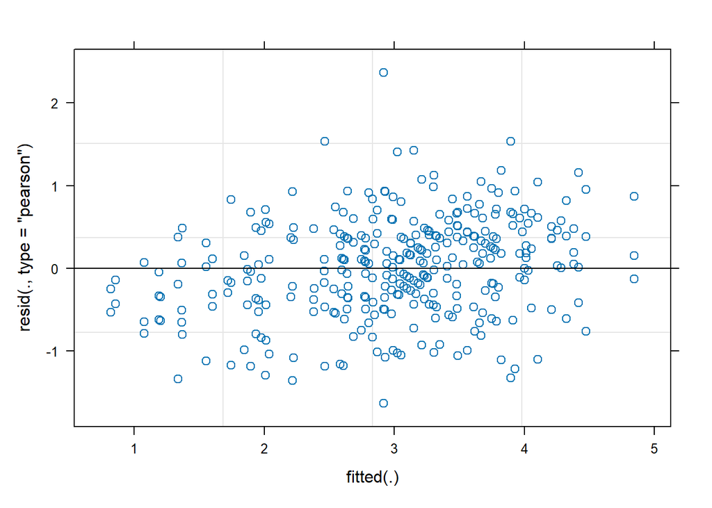

```r
plot(awe_aims)
```

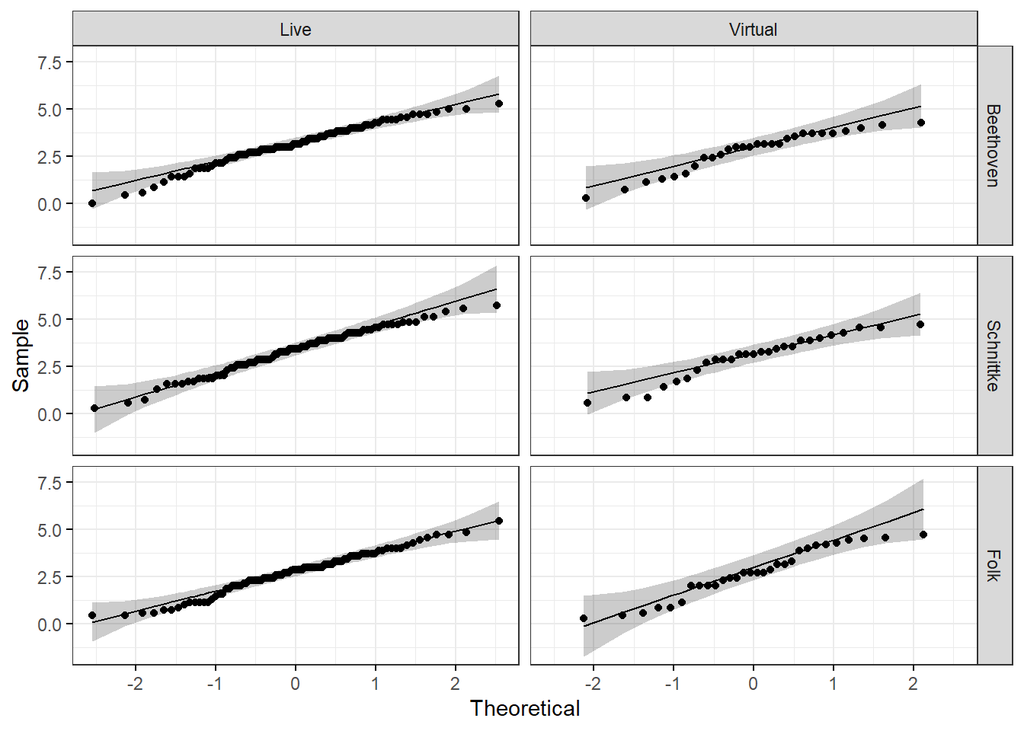

```r
#### QQPlot
ggqqplot(df_awe_aims.wide_nona, "AWE_wonder", ggtheme = theme_bw()) +
  facet_grid(piece ~ group)
```

Visualize the relation: Included in the supplementary material: figure 3

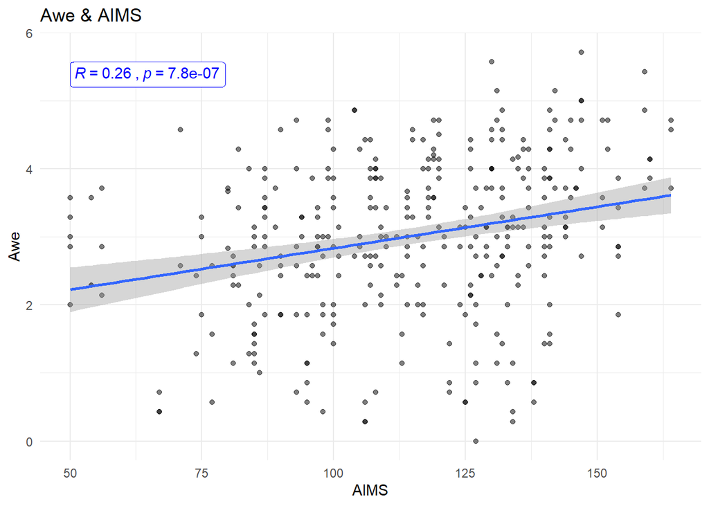

```r
title =  "Awe & AIMS"

# r
# p<-df_awe_aims.wide%>%
#   ggplot(aes(x = AIMS, y = AWE_wonder))+
#   geom_point(alpha = .5)+
#   labs(title =title,x = "AIMS", y = "Awe")+
#   geom_smooth(method = lm)+
#   facet_grid(rows = vars(piece), cols = vars(group))+
#   theme_minimal()+
#   stat_cor(aes(label = ..r.label..), color = "blue", geom = "label")

p<-df_awe_aims.wide%>%
  ggplot(aes(x = AIMS, y = AWE_wonder))+
  geom_point(alpha = .5)+
  labs(title =title,x = "AIMS", y = "Awe")+
  geom_smooth(method = lm)+
  #facet_grid(rows = vars(piece), cols = vars(group))+
  theme_minimal()+
  stat_cor(aes(label = paste(..r.label.., ..p.label.., sep = "~`,`~")), color = "blue", geom = "label")

p
```

```r
graphname<-paste0("../revised_plots/", title,".png")
ggsave(graphname, width = 15, height = 10, units = 'cm', dpi = 500)
```

## 3.3.3 Familiarity, Enjoyment, and Absorption

```r
df_famil_enjoy<-df.full%>%select("Pt_ID", contains(c("familiar", "enjoy", "mus_abs")))%>%select(!familiar_Bach)

df_famil_enjoy.long<-df_famil_enjoy%>%pivot_longer(!Pt_ID,
                        names_to = c("question", "piece"),
                        names_pattern ="(.*)_(.*)",
                        values_to = "response")

df_famil_enjoy.wide<-df_famil_enjoy.long%>%pivot_wider(names_from = question, values_from = response)

describe(df_famil_enjoy.wide)
```

```
##          vars   n  mean    sd median trimmed   mad  min max  range  skew
## Pt_ID*      1 408 68.50 39.31  68.50   68.50 50.41 1.00 136 135.00  0.00
## piece*      2 408  2.00  0.82   2.00    2.00  1.48 1.00   3   2.00  0.00
## familiar    3 363  2.46  2.21   2.00    2.33  2.97 0.00   6   6.00  0.23
## enjoy       4 364  5.02  1.26   5.00    5.25  1.48 0.00   6   6.00 -1.47
## mus_abs     5 368  4.11  1.14   4.33    4.15  0.99 0.67   6   5.33 -0.34
##          kurtosis   se
## Pt_ID*      -1.21 1.95
## piece*      -1.51 0.04
## familiar    -1.46 0.12
## enjoy        2.17 0.07
## mus_abs     -0.48 0.06
```

#### Familiarity

Being familiar with the music was positively correlated with absorption (r = .21, p = .001).

```r
fam_abs.rmc<-rmcorr(participant = "Pt_ID", measure1 = "familiar", measure2 = "mus_abs", dataset = df_famil_enjoy.wide)
fam_abs.rmc
```

```
##
## Repeated measures correlation
##
## r
## 0.2131897
##
## degrees of freedom
## 223
##
## p-value
## 0.001294936
##
## 95% confidence interval
## 0.08476256 0.3346493
```

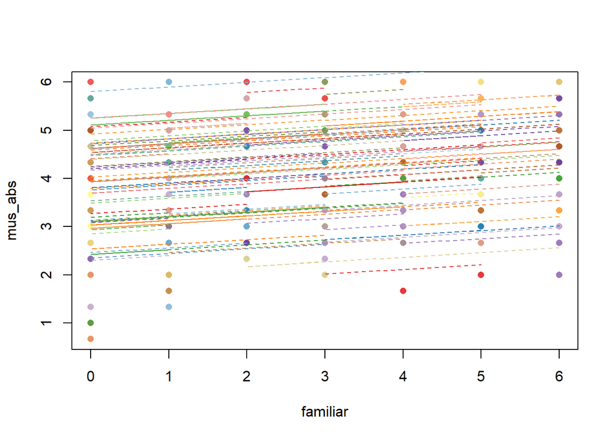

```r
plot(fam_abs.rmc, absorbed_factors, lty = 2)
```

#### Enjoyment

Enjoying the music was positively correlated with absorption (r = .61, p < .001). Recall that this result is simply correlational and not causational so there is no way to know whether enjoyment leads to better absorption or if absorption leads to enjoyment.

```r
enj_abs.rmc<-rmcorr(participant = "Pt_ID", measure1 = "enjoy", measure2 = "mus_abs", dataset = df_famil_enjoy.wide)
enj_abs.rmc
```

```
##
## Repeated measures correlation
##
## r
## 0.6080299
##
## degrees of freedom
## 223
##
## p-value
## 3.887229e-24
##
## 95% confidence interval
## 0.5184704 0.6843944
```

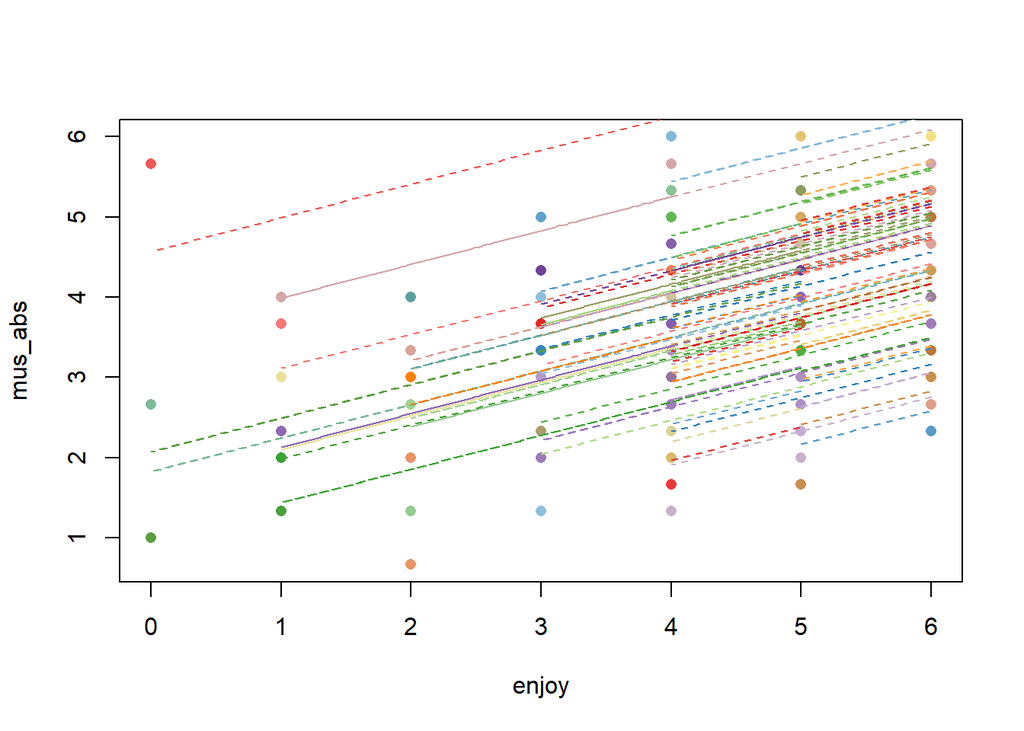

```r
plot(enj_abs.rmc, absorbed_factors, lty = 2)
```

# 3.4 Personal Characteristics and Absorption

2. What is the impact of previous musical training/acquaintance with the performed music/personal relation to the DSQ on absorption?

Personal Characteristics (EC, AIMS, Musician, Relationship, Fan) x Absorption

(Musical training, Acquaintance/familiarity with music, personal relations to the performers, empathy)

Use a multiple regression approach to assess which variables predict absorption.

Average absorption over the three pieces because personal characteristics are the same across pieces.

What is the relation between absorption and traits? * Empathic concern * AIMS * Musician Status * Personal Relation to the Performers * Fan status

```r
personal_variables<-c("EC", "AIMS", "musician_status", "personal_relation", "fan")

df_personal<-df.full%>%select(Pt_ID,group,all_of(personal_variables))

describe(df_personal)
```

```
##                    vars   n   mean    sd median trimmed   mad min max range
## Pt_ID*                1 136  68.50 39.40   68.5   68.50 50.41   1 136   135
## group*                2 136   1.33  0.47    1.0    1.29  0.00   1   2     1
## EC                    3 126   3.91  0.64    4.0    3.94  0.64   1   5     4
## AIMS                  4 122 114.25 24.96  117.0  115.31 26.69  50 164   114
## musician_status*      5 126   3.98  1.51    3.0    3.84  1.48   1   7     6
## personal_relation*    6 126   1.17  0.37    1.0    1.09  0.00   1   2     1
## fan                   7 124   5.06  2.41    6.0    5.32  1.48   1   7     6
##                     skew kurtosis   se
## Pt_ID*              0.00    -1.23 3.38
## group*              0.71    -1.51 0.04
## EC                 -0.83     2.23 0.06
## AIMS               -0.39    -0.39 2.26
## musician_status*    0.82    -0.42 0.13
## personal_relation*  1.77     1.13 0.03
## fan                -0.85    -0.97 0.22
```

```r
# average the absorption factors across all 3 pieces.
absorbed_mean<-musical_absorption.long%>%group_by(Pt_ID)%>%summarise(absorb_mean = mean(response))

df_personal_abs<-full_join(df_personal, absorbed_mean, by = c("Pt_ID"))

df_personal_abs_std<-standardize(df_personal_abs)
```

## Regression

DV: absorption (continuous)

IV: personal characteristics Continuous: EC, AIMS Ordinal: musician_status, fan Categorical: personal_relation

Multiple regression notes from the textbook (Field) The more predictors you add, the higher R^2 will be (explantory power of the model). Therefore the Aikake Information Criterion (AIC) is a better measure of the fit of a model. It penalizes extra predictors. (A little like adjusted R^2). The higher the AIC, the worse the model fit is. AIC can be used to compare models with the same outcome measure.

Care should be taken when selecting which predictors to be entered in the model. When predictors are all completely uncorrelated, then the order of entry into the model doesn’t matter as much. However there are rarely uncorrelated predictors.

Choosing parameter and their order: - Hierarchical: predictors are selected based on past research and the experimenter decides how to add them to the model, in order of importance of the predictor based on past research. New predictors suspected to be the most important should be entered first. - Forced entry: all predictors are added without consideration for order. - Stepwise: R mathematically assesses whether the addition of a predictor contributed to better fit or not with the AIC. The backwards selection approach leads to less suppressor effects than the forward selection approach so it should be favoured. However generally statisticians frown upon stepwise regression approaches. - All subsets method: tests all combinations of the predictors. With 6 variables, it will be 64 combinations (2**6). This shouldn’t be too computationally intensive.

What method to choose? Use theoretical literature to include meaningful variables in their order of importance first, then repeat the regression, but exclude variables that were statistically redundant the first time.

#### Step 1: Think critically about the variables and what would be most likely to influence absorption.

The AIMS should be the variable that most influences a propensity to be absorbed (because that is exactly what it is supposed to measure). Then fan-status is likely to be important for fostering feelings of absorption, based on my own musical experiences. I would not know what would be most important between EC, musician status, and personal relation. Perhaps one approach would be to examine the correlations.

#### Step 2: Correlations

Interestingly, the correlation indicates that fan-status may actually be more related to participants’ experiences of absorption than AIMS.

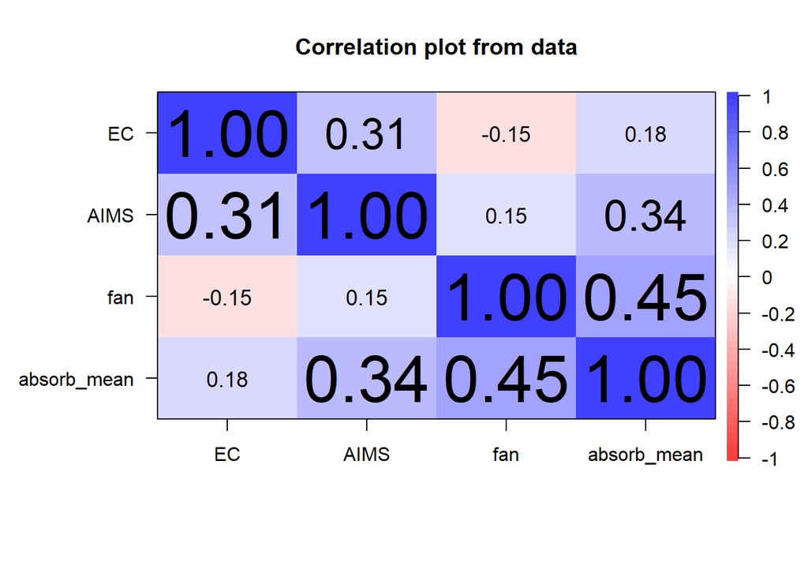

```r
cor_df_personal_chars<-df_personal_abs%>%select(-Pt_ID, -musician_status, -personal_relation, -group)
cor.plot(cor_df_personal_chars, numbers = TRUE)

cor_df_personal_chars_std<-df_personal_abs_std%>%select(-Pt_ID, -musician_status, -personal_relation, -group)
cor.plot(cor_df_personal_chars_std, numbers = TRUE)
```

#### Step 3: Make the model

##### Set the categorical contrasts

```r
# Musician Status
summary(df_personal_abs$musician_status)
```

```
##                 Tone-deaf               Nonmusician  Music-loving nonmusician
##                         1                         8                        60
##          Amateur musician  Serious amateur musician Semiprofessional musician
##                        18                        17                         6
##     Professional musician                      NA's
##                        16                        10
```

```r
contrasts(df_personal_abs$musician_status)<-contr.treatment(7, base = 1)
#Baseline: tone-deaf. there is only one tone-deaf person though so maybe we should change the baseline to the group with the most number of people (3)
#df_personal_abs$musician_status # execute this to check contrasts.

# Personal Relation
summary(df_personal_abs$personal_relation)
```

```
##     No_Relation Relative_Friend            NA's
##             105              21              10
```

```r
contrasts(df_personal_abs$personal_relation)<-contr.treatment(2, base = 1)
#Baseline: no personal relation
#df_personal_abs$personal_relation # execute this to check contrasts.
```

##### Model

```r
m1<-lm(absorb_mean ~ AIMS + fan, data = df_personal_abs)
summary(m1) # Adjusted R-Squared = .27
```

```
##
## Call:
## lm(formula = absorb_mean ~ AIMS + fan, data = df_personal_abs)
##
## Residuals:
##      Min       1Q   Median       3Q      Max
## -1.86972 -0.54449  0.08746  0.53161  2.25316
##
## Coefficients:
##             Estimate Std. Error t value Pr(>|t|)
## (Intercept) 2.173771   0.379604   5.726  1.1e-07 ***
## AIMS        0.010339   0.003191   3.240  0.00163 **
## fan         0.159188   0.034366   4.632  1.1e-05 ***
## ---
## Signif. codes:  0 '***' 0.001 '**' 0.01 '*' 0.05 '.' 0.1 ' ' 1
##
## Residual standard error: 0.8005 on 99 degrees of freedom
##   (34 observations deleted due to missingness)
## Multiple R-squared:  0.2806, Adjusted R-squared:  0.266
## F-statistic: 19.31 on 2 and 99 DF,  p-value: 8.331e-08
```

```r
m1_std<-lm(absorb_mean ~ AIMS + fan, data = df_personal_abs_std)
summary(m1_std) # Adjusted R-Squared = .27 (stadnrdizing made no difference! phewf!)
```

```
##
## Call:
## lm(formula = absorb_mean ~ AIMS + fan, data = df_personal_abs_std)
##
## Residuals:
##      Min       1Q   Median       3Q      Max
## -2.00361 -0.58348  0.09372  0.56967  2.41450
##
## Coefficients:
##             Estimate Std. Error t value Pr(>|t|)
## (Intercept)  0.03042    0.08527   0.357  0.72203
## AIMS         0.27653    0.08536   3.240  0.00163 **
## fan          0.41143    0.08882   4.632  1.1e-05 ***
## ---
## Signif. codes:  0 '***' 0.001 '**' 0.01 '*' 0.05 '.' 0.1 ' ' 1
##
## Residual standard error: 0.8579 on 99 degrees of freedom
##   (34 observations deleted due to missingness)
## Multiple R-squared:  0.2806, Adjusted R-squared:  0.266
## F-statistic: 19.31 on 2 and 99 DF,  p-value: 8.331e-08
```

```r
m2<-update(m1, .~. + personal_relation + musician_status + EC)
summary(m2)
```

```
##
## Call:
## lm(formula = absorb_mean ~ AIMS + fan + personal_relation + musician_status +
##     EC, data = df_personal_abs)
##
## Residuals:
##      Min       1Q   Median       3Q      Max
## -1.84111 -0.46009  0.04168  0.54699  2.04389
##
## Coefficients:
##                     Estimate Std. Error t value Pr(>|t|)
## (Intercept)         1.838689   0.882074   2.085   0.0399 *
## AIMS                0.008817   0.003826   2.305   0.0235 *
## fan                 0.163344   0.037513   4.354 3.49e-05 ***
## personal_relation2  0.197286   0.245962   0.802   0.4246
## musician_status2   -0.607988   0.892009  -0.682   0.4972
## musician_status3   -0.361179   0.838815  -0.431   0.6678
## musician_status4   -0.422613   0.846941  -0.499   0.6190
## musician_status5   -0.758681   0.861030  -0.881   0.3806
## musician_status6   -0.710111   0.893317  -0.795   0.4287
## musician_status7   -0.872966   0.873743  -0.999   0.3204
## EC                  0.246861   0.138396   1.784   0.0778 .
## ---
## Signif. codes:  0 '***' 0.001 '**' 0.01 '*' 0.05 '.' 0.1 ' ' 1
##
## Residual standard error: 0.795 on 91 degrees of freedom
##   (34 observations deleted due to missingness)
## Multiple R-squared:  0.3479, Adjusted R-squared:  0.2762
## F-statistic: 4.854 on 10 and 91 DF,  p-value: 1.364e-05
```

```r
m2_std<-update(m1_std, .~. + personal_relation + musician_status + EC)
summary(m2_std)
```

```
##
## Call:
## lm(formula = absorb_mean ~ AIMS + fan + personal_relation + musician_status +
##     EC, data = df_personal_abs_std)
##
## Residuals:
##      Min       1Q   Median       3Q      Max
## -1.97294 -0.49303  0.04466  0.58616  2.19025
##
## Coefficients:
##                                          Estimate Std. Error t value Pr(>|t|)
## (Intercept)                               0.54271    0.88986   0.610   0.5435
## AIMS                                      0.23580    0.10232   2.305   0.0235
## fan                                       0.42217    0.09695   4.354 3.49e-05
## personal_relationRelative_Friend          0.21141    0.26357   0.802   0.4246
## musician_statusNonmusician               -0.65152    0.95588  -0.682   0.4972
## musician_statusMusic-loving nonmusician  -0.38704    0.89888  -0.431   0.6678
## musician_statusAmateur musician          -0.45287    0.90759  -0.499   0.6190
## musician_statusSerious amateur musician  -0.81301    0.92269  -0.881   0.3806
## musician_statusSemiprofessional musician -0.76096    0.95728  -0.795   0.4287
## musician_statusProfessional musician     -0.93548    0.93631  -0.999   0.3204
## EC                                        0.16844    0.09443   1.784   0.0778
##
## (Intercept)
## AIMS                                     *
## fan                                      ***
## personal_relationRelative_Friend
## musician_statusNonmusician
## musician_statusMusic-loving nonmusician
## musician_statusAmateur musician
## musician_statusSerious amateur musician
## musician_statusSemiprofessional musician
## musician_statusProfessional musician
## EC                                       .
## ---
## Signif. codes:  0 '***' 0.001 '**' 0.01 '*' 0.05 '.' 0.1 ' ' 1
##
## Residual standard error: 0.8519 on 91 degrees of freedom
##   (34 observations deleted due to missingness)
## Multiple R-squared:  0.3479, Adjusted R-squared:  0.2762
## F-statistic: 4.854 on 10 and 91 DF,  p-value: 1.364e-05
```

```r
# musician status and personal relation are having little to no effect

m3<-update(m1, .~. + personal_relation)
summary(m3)
```

```
##
## Call:
## lm(formula = absorb_mean ~ AIMS + fan + personal_relation, data = df_personal_abs)
##
## Residuals:
##      Min       1Q   Median       3Q      Max
## -1.84351 -0.52436  0.08895  0.53008  2.26062
##
## Coefficients:
##                    Estimate Std. Error t value Pr(>|t|)
## (Intercept)        2.201323   0.382099   5.761 9.65e-08 ***
## AIMS               0.010105   0.003213   3.145   0.0022 **
## fan                0.153755   0.035162   4.373 3.06e-05 ***
## personal_relation2 0.172214   0.224952   0.766   0.4458
## ---
## Signif. codes:  0 '***' 0.001 '**' 0.01 '*' 0.05 '.' 0.1 ' ' 1
##
## Residual standard error: 0.8022 on 98 degrees of freedom
##   (34 observations deleted due to missingness)
## Multiple R-squared:  0.2849, Adjusted R-squared:  0.263
## F-statistic: 13.01 on 3 and 98 DF,  p-value: 3.191e-07
```

```r
# confirmed: personal_relation has no effect

m4<-update(m1, .~. + musician_status)
summary(m4)
```

```
##
## Call:
## lm(formula = absorb_mean ~ AIMS + fan + musician_status, data = df_personal_abs)
##
## Residuals:
##     Min      1Q  Median      3Q     Max
## -1.9218 -0.5735  0.1540  0.5423  2.0808
##
## Coefficients:
##                   Estimate Std. Error t value Pr(>|t|)
## (Intercept)       2.279017   0.842939   2.704 0.008155 **
## AIMS              0.011986   0.003489   3.436 0.000885 ***
## fan               0.155332   0.035786   4.341 3.61e-05 ***
## musician_status2 -0.146855   0.867893  -0.169 0.866000
## musician_status3 -0.136527   0.832546  -0.164 0.870097
## musician_status4 -0.223950   0.847048  -0.264 0.792065
## musician_status5 -0.557107   0.855930  -0.651 0.516729
## musician_status6 -0.534987   0.895589  -0.597 0.551720
## musician_status7 -0.601926   0.866105  -0.695 0.488800
## ---
## Signif. codes:  0 '***' 0.001 '**' 0.01 '*' 0.05 '.' 0.1 ' ' 1
##
## Residual standard error: 0.8025 on 93 degrees of freedom
##   (34 observations deleted due to missingness)
## Multiple R-squared:  0.3209, Adjusted R-squared:  0.2624
## F-statistic: 5.492 on 8 and 93 DF,  p-value: 1.104e-05
```

```r
# try with musical non-musician as baseline.
contrasts(df_personal_abs$musician_status)<-contr.treatment(7, base = 3)
m5<-update(m1, .~. + musician_status)
summary(m5) # still no sig differences between the musician status groups
```

```
##
## Call:
## lm(formula = absorb_mean ~ AIMS + fan + musician_status, data = df_personal_abs)
##
## Residuals:
##     Min      1Q  Median      3Q     Max
## -1.9218 -0.5735  0.1540  0.5423  2.0808
##
## Coefficients:
##                   Estimate Std. Error t value Pr(>|t|)
## (Intercept)       2.142490   0.423123   5.064 2.07e-06 ***
## AIMS              0.011986   0.003489   3.436 0.000885 ***
## fan               0.155332   0.035786   4.341 3.61e-05 ***
## musician_status1  0.136527   0.832546   0.164 0.870097
## musician_status2 -0.010328   0.337825  -0.031 0.975677
## musician_status4 -0.087423   0.248384  -0.352 0.725659
## musician_status5 -0.420580   0.246637  -1.705 0.091484 .
## musician_status6 -0.398460   0.377280  -1.056 0.293641
## musician_status7 -0.465399   0.280612  -1.659 0.100583
## ---
## Signif. codes:  0 '***' 0.001 '**' 0.01 '*' 0.05 '.' 0.1 ' ' 1
##
## Residual standard error: 0.8025 on 93 degrees of freedom
##   (34 observations deleted due to missingness)
## Multiple R-squared:  0.3209, Adjusted R-squared:  0.2624
## F-statistic: 5.492 on 8 and 93 DF,  p-value: 1.104e-05
```

```r
m6<-update(m1, .~. + EC)
summary(m6) # empathic concern is only trending as a predictor for absorption # Adjusted R-Squared = .28
```

```
##
## Call:
## lm(formula = absorb_mean ~ AIMS + fan + EC, data = df_personal_abs)
##
## Residuals:
##     Min      1Q  Median      3Q     Max
## -1.7882 -0.5345  0.1022  0.5943  2.2060
##
## Coefficients:
##             Estimate Std. Error t value Pr(>|t|)
## (Intercept) 1.491692   0.550927   2.708   0.0080 **
## AIMS        0.008279   0.003388   2.444   0.0163 *
## fan         0.170063   0.034646   4.909 3.66e-06 ***
## EC          0.220817   0.130341   1.694   0.0934 .
## ---
## Signif. codes:  0 '***' 0.001 '**' 0.01 '*' 0.05 '.' 0.1 ' ' 1
##
## Residual standard error: 0.7931 on 98 degrees of freedom
##   (34 observations deleted due to missingness)
## Multiple R-squared:  0.301,  Adjusted R-squared:  0.2797
## F-statistic: 14.07 on 3 and 98 DF,  p-value: 1.066e-07
```